# Introdução à linguagem R

## Introdução

O objetivo desta seção é **apresentar os aspectos básicos da linguagem R** para que qualquer pessoa possa realizar todos os passos para a análise de dados nessa linguagem. Nela, abordaremos as questões mais básicas sobre a linguagem como: 1) R e RStudio, 2) funcionamento da linguagem, 3) estrutura e manipulação de objetos, 4) *tidyverse* e 5) principais livros e diversos materiais de R para se aprofundar nos estudos.

Todo processo de aprendizagem torna-se mais efetivo quando a **teoria é combinada com a prática**, então recomendamos fortemente que você leitor, acompanhe os códigos e exercícios deste livro, ao mesmo tempo que os executa em seu computador, e não só os leia passivamente. Por motivos de espaço, não abordaremos todas as questões relacionadas ao uso da linguagem R nesta seção. Logo, aconselhamos que o leitor consulte o material sugerido no final dessa seção para se aprofundar.

## R e RStudio

No final dos anos 1990, **Robert Gentleman** e **Ross Ihaka** (Auckland University, NZ), iniciaram o desenvolvimento da **versão free da linguagem S**, com o seguinto histórico: Desenvolvimento (1997-2000), Versão 1 (2000-2004), Versão 2 (2004-2013), Versão 3 (2013-2020) e Versão 4 (2020). Para mais detalhes do histório de desenvolvimento do S e R, consultar Wickham (2013), sendo que atualmente a linguagem R é mantida por uma rede de colaboradores denominada **R Core Team**. A **origem do nome R** é desconhecida, mas reza que ao lançarem o nome da linguagem os autores se valeram da letra que vinha antes do S, uma vez que a linguagem R foi baseada nela, e utilizaram a letra “R”.

Um aspecto digno de nota é que a linguagem R, ao contrário de outras linguagem como Fortran e C que são compiladas, é uma **linguagem interpretada**, o que a faz ser mais fácil de programar, pois processa linhas de comando e as transforma em linguagem de máquina (código binário que o computador efetivamente lê), apesar desse fato diminuir a velocidade de processamento.

Para começarmos a trabalhar com o R é necessário baixá-lo na página do R Project. Então, acesse esse [site](http://www.r-project.org), e em seguida, clique no link **download R**, que o levará à pagina do CRAN Mirros (*Comprehensive R Archive Network*). Escolha a **página espelho do Brasil** mais próxima de você para baixar o programa. Escolha agora o **sistema operacional** do seu computador (passos adicionais existem para diferentes distribuições Linux), para Windows, clique em **base** para finalmente chegar à **página de download** com a versão mais recente do R.

Reserve algum tempo posteriormente para **explorar esta página do R-Project**. Existem vários [livros](http://www.r-project.org/doc/bib/R-books.html) dedicados a diversos assuntos baseados no R. Além disso, estão disponíveis [manuais](http://cran.r-project.org/manuals.html) em [diversas línguas](http://cran.r-project.org/other-docs.html) para serem baixados gratuitamente.

Como o R é um software livre, não existe a possibilidade de o usuário entrar em **contato com um serviço de suporte de usuários**, muito comuns em softwares pagos. Ao invés disso, existem várias listas de emails que fornecem suporte à [comunidade de usuários](http://www.r-project.org/mail.html). Nós, particularmente, recomendamos o ingresso nas seguintes listas: R-help, R-sig-ecology, e [R-br](http://www.leg.ufpr.br/doku.php/software:rbr). Este último representa um grupo de usuários brasileiro do programa R.

Apesar de podemos utilizar o R com a IDE (Ambiente de Desenvolvimento Integrado - *Integrated Development Environment*) RGui que vem com a instalação da linguagem, para usuários Windows (Figura @ref(fig:fig-rgui)) ou no próprio terminal para usuários Linux e MacOS, existem alguns IDEs específicos para facilitar nosso uso dessa linguagem.

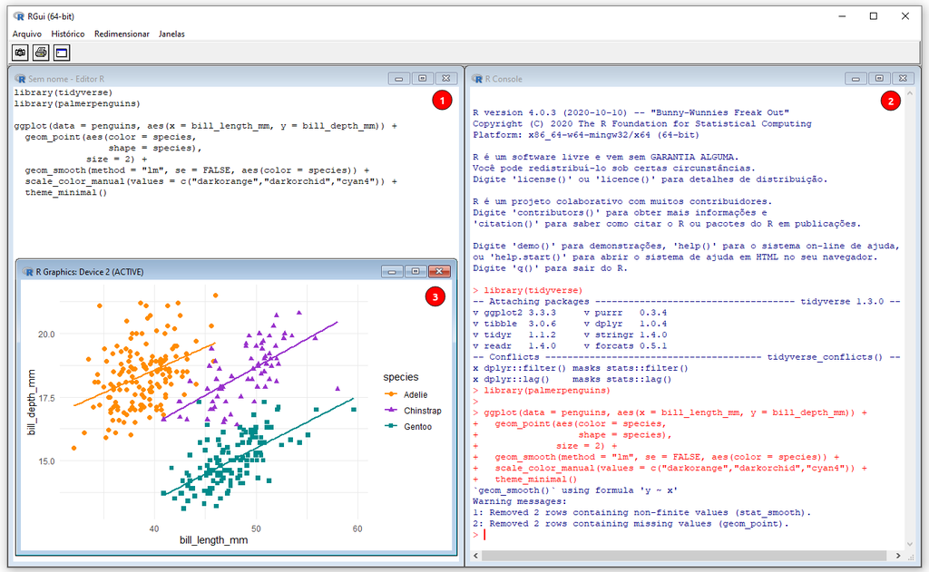

Interface do RGui. Os números indicam: (1) R Script, (2) R Console, e (3) R Graphics.

Entretanto, desde 2011, um IDE se tornou mais popular na comunidade: o [RStudio](https://rstudio.com/) (Figura @ref(fig:fig-rstudio)). O RStudio possui algumas características que o tornam tão popular: várias janelas de visualização, marcação e preenchimento automático do script, integração com controle de versão, dentre outras opções. Para fazer o download do RStudio, acessamos o [site](https://rstudio.com/products/rstudio/download/#download), e escolhemos o instalador com base em nosso sistema operacional.

Um último ponto técnico importante: para evitar possíveis erros, é interessante instalar primeiro a linguagem R, seguida do IDE RStudio.

## Funcionamento da linguagem R

Nesta seção veremos o **principais conceitos** para entender como a **linguagem funciona** ou como geralmente utilizamos o IDE RStudio no dia-a-dia, para executar nossas rotinas utilizando a linguagem R. Veremos então: 1) console, 2) script (editor/roteiro), 3) objetos (variáveis), 4) operadores, 5 ) funções, 6) pacotes, 7) ambiente (environment/workspace), 8) ajuda (help) e 9) citações.

Antes de iniciarmos propriamente dito, é fundamental entendermos alguns pontos sobre as janelas e o funcionamento delas no RStudio (Figura @ref(fig:fig-rstudio)).

[figure not shown]

Interface do RStudio. Os números indicam: (1) janelas com abas de Script e R Markdown; (2) janela com abas de Console, Terminal e Jobs; (3) janela com abas de Environment, History, Conections e Tutorial; e (4) janela com abas de Files, Plots, Packages, Help e Viewer.

Detalhando algumas dessas janelas, temos:

- **Console**: é onde os códigos são rodados e vemos as saídas
- **Editor/Script**: é onde escrevemos nossos códigos em R ou R Markdown
- **Environment**: painel com todos os objetos criados na sessão
- **History**: painel com o histórico dos comandos rodados
- **Files**: painel que mostra os arquivos no diretório de trabalho
- **Plots**: painel onde os gráficos são apresentados
- **Packages**: painel que lista os pacotes
- **Help**: painel onde a documentação das funções é exibida

No RStudio, alguns atalhos são fundamentais para aumentar nossa produtividade:

- **f1**: abre o painel de *Help*
- **ctrl + Enter**: roda a linha selecionada no script
- **ctrl + Shift + N**: abre um novo script
- **ctrl + S**: salva um script
- **ctrl + Z**: desfaz uma operação
- **ctrl + shift + Z**: refaz uma operação
- **alt + -**: insere um sinal de atribuição (<-)
- **ctrl + Shift + M**: insere um operador pipe (%>%)
- **ctrl + Shift + C**: comenta uma linha no script - insere um (#)
- **ctrl + Shift + R**: insere uma sessão (# ———————-)
- **ctrl + Shift + H**: abre uma janela para selecionar o diretório de trabalho
- **ctrl + Shift + f10**: reinicia o console
- **ctrl + L**: limpa os comandos do console
- **alt + Shift + K**: abre uma janela com todos os atalhos disponíveis

### Console

```r
10 + 2
```

```
## [1] 12
```

O resultado retorna o valor `12`, precedido de um valor entre colchetes. Esses colchetes demonstram a posição do elemento numa sequência de valores. Se fizermos essa outra operação `1:42`, o R vai criar uma sequência unitária de valores de 1 a 42. A depender da largura da janela do console, vai aparecer um número diferente entre colchete indicando sua posição na sequência: antes do 1 vai aparecer o `[1]`, depois quando a sequência for quebrada, vai aparecer o número correspondente da posição do elemento, no nosso caso `[26]`.

```r
1:42
```

```
##  [1]  1  2  3  4  5  6  7  8  9 10 11 12 13 14 15 16 17 18 19 20 21 22 23 24 25
## [26] 26 27 28 29 30 31 32 33 34 35 36 37 38 39 40 41 42
```

Podemos ver o hitórico dos código executados no Console na aba **History** (Figura @ref(fig:fig-rstudio) (3)).

### Scripts

Scripts são **rascunhos dos códigos**, e onde de fato os códigos são escritos e depois enviados ao console (Figura @ref(fig:fig-rstudio) (1)). Scripts são arquivos de texto simples, criados com a extensão (terminação) `.R`. Para criar um script basta ir em `File > New File > R Script`, ou clicando no ícone logo abaixo de File, ou ainda usando o atalho `ctrl + shift + N`.

Uma vez escrito os códigos no script, podemos rodar esses códigos de duas formas: 1) todo o script de uma vez, clicando em **Source** ou usando o atalho `ctrl + shift + enter`; 2) a linha onde o cursos estiver posicionado, independente de sua posição naquela linha, clicando em **Run** ou usando o atalho `ctrl + enter`.

Devemos sempre **salvar nossos scripts**, tomando por via de regra: primeiro criar o arquivo e depois ir salvando versão desse mesmo arquivo. Há diversos motivos para criar um script: continuar o desenvolvimento do mesmo em outro momento ou em outro computador, preservar trabalhos passados, ou ainda compartilhar seus códigos com outra pessoa. Para criar ou salvar um script basta ir em `File > Save`, escolher um diretório e nome para o script, e salvar. Podemos ainda utilizar o atalho `ctrl + S`.

Em relação aos scripts, ainda há os **comentários**, representados pelos símbolos `#` (hash) ou `#'` (hash-linha). Comentários não são lidos pelo console do R e são utilizados geralmente para descrever informações sobre dados ou funções, ou ainda para suprimir linhas de código. É interessante ter no início de cada script um cabeçalho identificando o objetivo ou análise, autor e data.

```r
#' ---
#' title: capitulo 04 - introducao ao r
#' author: mauricio vancine
#' date: 2021-02-26
#' ---
```

Além disso, podemos usar comentários para adicionar informações sobre os códigos.

```r
# comentarios
# o r nao le o codigo depois do # (hash)
42 # essas palavras nao sao executadas, apenas o 42
```

```
## [1] 42
```

Um ponto muito importante é escrever os comentários sempre em inglês para tornar seu código mais reprodutível possível. Por fim, outro ponto fundamental é ter **boas práticas de estilo de código**. Quanto mais organizado e padronizado estiver os scripts, mais fácil de entendê-los e de procurar possíveis erros. Existem dois guias de boas práticas para adequadar seus scripts: [Hadley Wickham](http://adv-r.had.co.nz/Style.html) e [Google](https://google.github.io/styleguide/Rguide.xml).

### Operadores

No R, temos **cinco tipos de operadores**: aritméticos, relacionais, lógicos, atribuição e diversos. Todos são descritos na Tabela @ref(tab:tab-operadores).

Operadores no R.

| Operador | Tipo | Descrição |
| --- | --- | --- |
| + | Aritmético | Adição |
| - | Aritmético | Subtração |
| * | Aritmético | Multiplicação |
| / | Aritmético | Divisão |
| %% | Aritmético | Resto da divisão |
| %/% | Aritmético | Divisão inteira |
| ^ ou ** | Aritmético | Expoente |
| > | Relacional | Maior |
| < | Relacional | Menor |
| >= | Relacional | Maior ou igual |
| <= | Relacional | Menor ou igual |
| == | Relacional | Igualdade |
| != | Relacional | Diferença |
| ! | Lógico | Lógico NÃO |
| & | Lógico | Lógico elementar E |
| \| | Lógico | Lógico elementar OU |
| && | Lógico | Lógico E |
| \|\| | Lógico | Lógico OU |
| <- ou = | Atribuição | Atribuição à esquerda |
| <<- | Atribuição | Super atribuição à esquerda |
| -> | Atribuição | Atribuição à direita |
| ->> | Atribuição | Super atribuição à direita |
| : | Diversos | Sequência unitária |
| %in% | Diversos | Elementos que pertencem a um vetor |
| %*% | Diversos | Multiplar matriz com sua transposta |
| %>% | Diversos | pipe |
| %–% | Diversos | Intervalo de datas |

Como exemplo, podemos fazer operações simples usando os operadores aritméticos.

```r
# operacoes aritmeticas
10 + 2 # adicao
```

```
## [1] 12
```

```r
10 * 2 # multiplicacao
```

```
## [1] 20
```

Precisamos ficar atentos à **dominância** dos operadores aritméticos: `^ >> * ou / >> + ou -`. Veja no exemplo abaixo como o uso dos parênteses mudam os resultados.

```r
# sem especificar - segue a ordem dos operadores
1 * 2 + 2 / 2 ^ 2
```

```
## [1] 2.5
```

```r
# especificando - segue a ordem dos parenteses
((1 * 2) + (2 / 2)) ^ 2
```

```
## [1] 9
```

### Objetos

**Objetos** são **palavras** às quais são **atribuídos dados**. Essa atribuição possibilita a manipulação de dados ou resultados de análises. Iremos utilizar os símbolos `<` (menor), seguido de `-` (menos), sem espaço, dessa forma `<-`. Também podemos utilizar o símbolo de igual (`=`), mas não recomendamos, por não fazer parte das boas práticas de escrita de códigos em R. Podemos inserir essa combinação de símbolos com o atalho `alt + -`. Para demonstrar, vamos atribuir o valor `10` à palavra `obj_10`, e chamar esse objeto novamente para verificar seu conteúdo.

```r
# atribuicao - simbolo (<-)
obj_10 <- 10
obj_10
```

```
## [1] 10
```

Todos os objetos criados numa sessão do R ficam listados na aba **Environment** (Figura @ref(fig:fig-rstudio) (3)). Além disso, o RStudio possui a função *auto complete*, ou seja, podemos digitar as primeiras letras de um objeto (ou função) e em seguida apertar `Tab` para que o RStudio liste tudo que começar com essas letras.

Dois pontos importantes sobre atribuições: primeiro, o R sobrescreve os valores dos objetos com o mesmo nome, deixando o objeto com o valor da segunda atribuição.

```r
# sobrescreve o valor dos objetos
obj <- 100
obj
```

```
## [1] 100
```

```r
# obj agora vale 2
obj <- 2
obj
```

```
## [1] 2
```

Segundo, o R tem limitações ao nomear objetos:

- nome de objetos só podem **começar por letras** (`a-z` ou `A-Z`) ou **pontos** (`.`)
- nome de objetos só podem **conter letras** (`a-z` ou `A-Z`), **número**s (`0-9`), **underscores** (`_`) ou **pontos** (`.`)
- R é *case-sensitive*, i.e., ele difere **letras maiúsculas de minúsculas**. Assim, um objeto chamado “resposta” é diferente do objeto “RESPOSTA”
- devemos **evitar acentos ou cedilha** (`ç`) para facilitar a memorização dos objetos
- nome de objetos não podem ser iguais a **nomes especies** (`break`, `else`, `FALSE`, `for`, `function`, `if`, `Inf`, `NA`, `NaN`, `next`, `repeat`, `return`, `TRUE`, `while`)

Podemos ainda utilizar objetos para **fazer operações e criar novos objetos**. Isso pode parecer um pouco confuso para os iniciantes na linguagem, mas é fundamental aprender essa lógica para passar para os próximos passos.

```r
# definir dois objetos
va1 <- 10
va2 <- 2

# operacoes com objetos e atribuicao
adi <- va1 + va2
adi
```

```
## [1] 12
```

### Funções

Funções são **códigos preparados para realizar uma tarefa** de modo simples. Outra forma de entender uma função é: comandos que realizam operações em argumentos. A estrutura de uma função é muito similar à sintaxe usada em planilhas eletrônicas, sendo composta por:

> nome_da_funcao(argumento1, argumento2)
1. **Nome da função**: remete ao que ela faz
2. **Parênteses**: limitam a função
3. **Argumentos**: onde a função irá atuar
4. **Vírgulas**: separam os argumentos

Os argumentos de uma função podem ser de dois tipos:

1. **Valores ou objetos**: a função irá alterar os valores em si ou os valores atribuídos aos objetos
2. **Parâmetros**: valores fixos que informam um método ou a realização de uma operação. Informa-se o nome desse argumento, seguido de “=” e um número, texto ou TRUE ou FALSE

Alguns exemplos de argumentos como valores ou objetos.

```r
# funcoes - argumentos como valores
# soma
sum(10, 2)
```

```
## [1] 12
```

```r
# funcoes - argumentos como objetos
# soma
sum(va1, va2)
```

```
## [1] 12
```

Alguns exemplos de argumentos como parâmetros. Note que apesar do valor do argumento ser o mesmo (10), seu efeito no resultado muda drasticamente. Aqui também é importante destacar um ponto: 1 podemos informar os argumentos sequencialmente, sem explicitar seus nomes, ou 2) independente da ordem, mas explicitando seus nomes. Entretanto, como no exemplo abaixo, devemos informar o nome do argumento (i.e., parâmetro), para que seu efeito seja o que desejamos.

```r
# funcoes - argumentos como parametros
# repeticao - repita todos os elementos
rep(x = 1:5, times = 10)
```

```
##  [1] 1 2 3 4 5 1 2 3 4 5 1 2 3 4 5 1 2 3 4 5 1 2 3 4 5 1 2 3 4 5 1 2 3 4 5 1 2 3
## [39] 4 5 1 2 3 4 5 1 2 3 4 5
```

```r
# repeticao - repita cada um dos elementos
rep(x = 1:5, each = 10)
```

```
##  [1] 1 1 1 1 1 1 1 1 1 1 2 2 2 2 2 2 2 2 2 2 3 3 3 3 3 3 3 3 3 3 4 4 4 4 4 4 4 4
## [39] 4 4 5 5 5 5 5 5 5 5 5 5
```

Um ponto fundamental, e que deve ser entendido nesse ponto, é o **fluxo de atribuições do resultado da operação de funções a novos objetos**. No desenvolvimento de qualquer script, grande parte da estrutura do mesmo será dessa forma: atribuição de dados > operações com funções > atribuição dos resultados a novos objetos > operações com funções desses novos objetos > atribuição dos resultados a novaos objetos….Ao entender esse funcionamento, começamos a entender como devemos pensar na organização do nosso script para montar as análises de que precisamos.

```r
# atribuicao dos resultados
# repeticao
rep_times <- rep(x = 1:5, times = 10)
rep_times
```

```
##  [1] 1 2 3 4 5 1 2 3 4 5 1 2 3 4 5 1 2 3 4 5 1 2 3 4 5 1 2 3 4 5 1 2 3 4 5 1 2 3
## [39] 4 5 1 2 3 4 5 1 2 3 4 5
```

```r
# somar e atribuir
rep_times_soma <- sum(rep_times)
rep_times_soma
```

```
## [1] 150
```

```r
# raiz e atribuir
rep_times_soma_raiz <- sqrt(rep_times_soma)
rep_times_soma_raiz
```

```
## [1] 12.24745
```

Por fim, é fundamental também entender a **origem das funções** que usamos no R. Todas as funções são advindas de **pacotes**. Esses pacotes possuem duas origens.

1. pacotes já instalados por padrão e que são carregados quando abrimos o R (*R Base*)
2. pacotes que instalamos e carregamos com funções

### Pacotes

Pacotes são **conjunto extras de funções para executar tarefas específicas**, além do *R Base*. Existe literalmente milhares de pacotes para as mais diversas tarefas: estatística, ecologia, geografia, sensoriamento remoto, econometria, ciências sociais, gráficos, *machine learning* etc. Podemos verificar este vasto conjunto de pacotes pelo [link](https://cran.r-project.org/web/packages/available_packages_by_name.html) que lista por nome os **pacotes oficiais**, ou seja, que passaram pelo crivo do **CRAN**. Existem ainda muito mais **pacotes em desenvolvimento**, geralmente disponibilizados em repositórios do **GitHub ou GitLab**.

Primeiramente, com uma sessão do R sem carregar nenhum pacote extra, podemos verificar pacotes carregados pelo *R Base* utilizando a função `search()`.

```r
# verificar pacotes carregados
search()
```

Podemos ainda verificar todos pacotes instalados em seu computador com a função `library()`.

```r
# verificar pacotes instalados
library()
```

No R, quando tratamos de pacotes, devemos destacar dois conceitos: instalar um pacote e carregar um pacote. A **instalação** de pacotes possui algumas características:

- Instala-se apenas uma vez
- Precisa estar conectado à internet
- O nome do pacote precisa estar entre aspas
- Função (CRAN): `install.packages()`

Vamos instalar o pacote *vegan* diretamente do CRAN, que possui funções para realizar uma série de análise em ecologia. Para isso, podemos ir em `Tools > Install Packages...`, ou ir na aba **Packages** (Figura @ref(fig:fig-rstudio) (4)), procurar um pacote ou simplesmente clicar em “Install”. Podemos ainda utilizar a função `install.packages()`.

```r
# instalar pacotes
install.packages("vegan")
```

Podemos conferir em que diretório um pacote é instalado com a função `.libPaths()`.

```r
# diretorio de intalacao dos pacotes
.libPaths()
```

```
## [1] "/home/mude/R/x86_64-pc-linux-gnu-library/4.0"
## [2] "/usr/local/lib/R/site-library"
## [3] "/usr/lib/R/site-library"
## [4] "/usr/lib/R/library"
```

Uma vez instalado um pacote, não há necessidade de instalá-lo novamente. Entretanto, todas as vezes que iniciarmos uma sessão no R, precisamos **carregar** os pacotes com as funções que precisamos utilizar. O **carregamento** de pacotes possui algumas características:

- Carrega-se toda vez que se abre uma nova sessão do R
- Não precisa estar conectado à internet
- O nome do pacote não precisa estar entre aspas
- Funções: `library()` ou `require()`

Vamos carregar o pacote *vegan* que instalamos anteriormente. Podemos ir na aba **Packages** (Figura @ref(fig:fig-rstudio) (4)) e ticar o pacote que queremos carregar ou utilizar a função `library()`.

```r
# carregar pacotes
library(vegan)
```

Como dissemos anteriormente, alguns pacotes em desenvlvimento encontram-se disponíveis em repositórios do GitHub ou GitLab. Para instalar pacotes do GitHub, por exemplo, precisamos instalar e carregar o pacote *devtools*.

```r
# instalar pacote devtools
install.packages("devtools")

# carregar pacote devtools
library(devtools)
```

Uma vez instalado e carregado este pacote, podemos instalar o pacote do GitHub, utilizando a função `devtools::install_github()`. Precisamos atentar para usar essa forma “nome_usuario/nome_repositorio”, retirados do link do repositório de interesse. Como exemplo, podemos instalar mesmo pacote *vegan* do repositório do GitHub vegandevs/vegan, e depois utilizar a função `library()` para carregá-lo normalmente.

```r
# instalar pacote do github
devtools::install_github("vegandevs/vegan")

# carregar pacote do github
library("vegan")
```

A maioria dos pacotes vem com bancos de dados que podem ser acessados pela função `data()`. Esses bancos de dados podem ser usados para testar as funções do pacote. Se estiver com dúvida na maneira como você deve preparar a planilha para realizar uma análise específica, entre no help da função e veja os conjuntos de dados que estão no exemplo desta função. Como exemplo, vamos carregar os dados `dune` do pacote *vegan*.

```r
# carregar dados de um pacote
library(vegan)
data(dune)
dune[1:6, 1:6]
```

```
##   Achimill Agrostol Airaprae Alopgeni Anthodor Bellpere
## 1        1        0        0        0        0        0
## 2        3        0        0        2        0        3
## 3        0        4        0        7        0        2
## 4        0        8        0        2        0        2
## 5        2        0        0        0        4        2
## 6        2        0        0        0        3        0
```

Se por algum motivo precisarmos **desinstalar** um pacote, podemos utilizar a função `remove.packages()`. Já para **descarregar** um pacote, podemos usar a função `detach()`.

```r
# descarregar um pacote
detach("package:vegan", unload = TRUE)
```

E um último ponto fundamental de pacotes, diz respeito à **atualização** dos mesmos. Os pacotes são atualizados com frequência, e infelizmente ou felizmente (pois as atualizações podem oferecer algumas quebras entre pacotes), não se atualizam sozinhos. Muitas vezes, a instalação de um pacote pode depender da versão dos pacotes dependentes, e geralmente uma janela se abre que todos os pacotes dependentes sejam atualizados. Podemos ir na aba **Packages** (Figura @ref(fig:fig-rstudio) (4)) e clicar em “Update” ou usar a função `update.packages(ask = FALSE)` para atualizá-los, entretanto, essa é uma função que costuma demorar para terminar de rodar.

```r
# atualizacao dos pacotes
update.packages(ask = FALSE)
```

### Ajuda (*Help*)

Um importante passo para melhorar a usuabilidade e ter mais familiaridade com a linguagem R é aprender a usar a **ajuda de cada função**. Para tanto, podemos utilizar a função `help()` ou o operador `?`, depois de ter carregado o pacote, para abri uma nova aba (Figura @ref(fig:fig-rstudio) (4)) que possui diversas informações sobre a função de interesse. O arquivo de ajuda do R possui geralmente nove ou dez tópicos, que nos auxiliam muito no entendimento dos dados de entrada, argumento e que operações estão sendo realizadas:

- **Description**: resumo da função
- **Usage**: como utilizar a função e quais os seus argumentos
- **Arguments**: detalha os argumentos e como os mesmos devem ser especifidados
- **Details**: detalhes importantes para se usar a função
- **Value**: mostra como interpretar a saída (*output*) da função (os resultados)
- **Note**: notas gerais sobre a função
- **Authors**: autores da função
- **References**: referências bibliográficas para os métodos usados pra construir a função
- **See also**: funções relacionadas
- **Examples**: exemplos do uso da função. Às vezes pode ser útil copiar esse trecho e colar no R para ver como funciona e como usar a função.

Vamos realizar um exemplo, buscando o *help* da função `aov()`.

```r
# help
help(aov)
?aov
```

Além das funções, podemos buscas detalhes de um pacote em específico, para uma página simples do *help* utilizando a função `help()` ou o operador `?`. Entretanto, para uma opção que ofereça uma descrição detalhada e um índice de todas as funções do pacote, podemos utilizar a função `library()`, mas agora utilizando o argumento “help”, indicamos o pacote de interesse entre aspas.

```r
# help do pacote
help(vegan)
?vegan

# help detalhado
library(help = "vegan")
```

Outra ferramenta de busca é a página [rseek](http://www.rseek.org), na qual é possível buscar por um termo não só nos pacotes do R, mas também em listas de emails, manuais, páginas na internet e livros sobre o programa.

### Ambiente (*Environment*)

O ambiente *Environment* como vimos é onde os objetos criados são armazenados. É fundamental entender que um objeto é uma **alocação de um pequeno espaço na memória RAM** do seu computador, onde o R armazenará um valor ou o resultado de uma função, utilizando o nome que definimos. Sendo assim, se fizermos uma atribuição de um **objeto maior que o tamanho da memória RAM**, esse objeto **não será alocado**, e a atribuição não funcionará. Existem opções para contornar esse tipo de limitação, mas não abordaremos aqui. Entretanto, podemos utilizar a função `object.size()` para saber quanto espaço nosso objeto criado está alocando de memória RAM. O conceito de função é tratado na seção seguinte.

```r
# tamanho de um objeto
object.size(adi)
```

```
## 56 bytes
```

Podemos listar todos os objetos criados com a função `ls()` ou `objects()`.

```r
# listar todos os objetos
ls()
```

```
## [1] "adi"                 "dune"                "obj"
## [4] "obj_10"              "rep_times"           "rep_times_soma"
## [7] "rep_times_soma_raiz" "va1"                 "va2"
```

Podemos ainda remover objetos criados com a função `rm()` ou `remove()`. Ou ainda fazer uma função composta para remove todos os objetos do *Environment*.

```r
# remover um objeto
rm(adi)

# remover todos os objetos criados
rm(list = ls())
```

Quando usamos a função `ls()`, nenhum objeto é lista.

```r
# listar todos os objetos
ls()
```

```
## character(0)
```

Toda a vez que **fechamos o R**, os objetos criados são **apagados** do **enrironmental**. Dessa forma, em algumas ocasiões, por exemplo, análises estatísticas que demoram um grande tempo para serem realizadas, pode ser interessante **exportar alguns ou todos os objetos criados**. Para salvar todo os objetos, ou seja, todo o *workspace*, podemos ir em `Session -> Save Workspace As...` e escolher o nome do arquivo do *workspace*, por exemplo, “meu_workspace.RData”. Podemos ainda utilizar funções para essas tarefas. A função `save.image()` salva todo *workspace* com a extensão `.RData`.

```r
# salvar todo o workspace
save.image(file = "meu_workspace.RData")
```

Depois disso, podemos fechar o RStudio tranquilamente, e quando formos trabalhar novamente, carregar os objetos criados indo em `Session -> Load Workspace...`, ou utilizando a função `load()`.

```r
# carregar todo o workspace
load("meu_workspace.RData")
```

Entretanto, em algumas ocasiões, não precisamos salvar todos os objetos. Dessa forma, podemos salvar apenas alguns objetos específicos usando a função `save()`, também com a extensão `.RData`.

```r
# salvar apenas um objeto
save(obj1, file = "meu_obj.RData")

# salvar apenas um objeto
save(obj1, obj2, file = "meus_objs.RData")

# carregar os objetos
load("meus_objs.RData")
```

Ou ainda podemos saber apenas um objeto com a extensão `.rds`. Para isso, usamos as funções `saveRDS()` e `readRDS()`.

```r
# salvar um objeto para um arquivo
saveRDS(obj, file = "meu_obj.rds")

# carregar esse objeto
readRDS(file = "meu_obj.rds")
```

### Citações

Ao utilizar o R para realizar alguma análise em seus estudos ecológicos, é fundamental a citação do mesmo. Para saber como citar exatamente o R em artigos, existe uma função denominada `citation()`, que provê um formato genérico de citação e um BibTeX para arquivos LaTeX e R Markdown.

```r
# citacao do r
citation()
```

```
##
##
##   R Core Team (2021). R: A language and environment for statistical
##   computing. R Foundation for Statistical Computing, Vienna, Austria.
##   URL https://www.R-project.org/.
##
## A BibTeX entry for LaTeX users is
##
##   @Manual{,
##     title = {R: A Language and Environment for Statistical Computing},
##     author = {{R Core Team}},
##     organization = {R Foundation for Statistical Computing},
##     address = {Vienna, Austria},
##     year = {2021},
##     url = {https://www.R-project.org/},
##   }
##
## We have invested a lot of time and effort in creating R, please cite it
## when using it for data analysis. See also 'citation("pkgname")' for
## citing R packages.
```

No resultado dessa função, há uma mensagem muito interessante: “See also ‘citation(“pkgname”)’ for citing R packages.”. Dessa forma, aconselhamos os usuários de R a citar também os pacotes que utilizaram em suas análises para dar os devidos créditos aos desenvolvedores das funções implementadas nos pacotes. Como exemplo, vamos ver como fica a citação do pacote *vegan*.

```r
# citacao do pacote vegan
citation("vegan")
```

```
##
##
##   Jari Oksanen, F. Guillaume Blanchet, Michael Friendly, Roeland Kindt,
##   Pierre Legendre, Dan McGlinn, Peter R. Minchin, R. B. O'Hara, Gavin
##   L. Simpson, Peter Solymos, M. Henry H. Stevens, Eduard Szoecs and
##   Helene Wagner (2020). vegan: Community Ecology Package. R package
##   version 2.5-7. https://CRAN.R-project.org/package=vegan
##
## A BibTeX entry for LaTeX users is
##
##   @Manual{,
##     title = {vegan: Community Ecology Package},
##     author = {Jari Oksanen and F. Guillaume Blanchet and Michael Friendly and Roeland Kindt and Pierre Legendre and Dan McGlinn and Peter R. Minchin and R. B. O'Hara and Gavin L. Simpson and Peter Solymos and M. Henry H. Stevens and Eduard Szoecs and Helene Wagner},
##     year = {2020},
##     note = {R package version 2.5-7},
##     url = {https://CRAN.R-project.org/package=vegan},
##   }
##
## ATTENTION: This citation information has been auto-generated from the
## package DESCRIPTION file and may need manual editing, see
## 'help("citation")'.
```

### Principais erros de iniciantes

**Errar** quando se está iniciando com R é **muito comum e faz parte do aprendizado**. Entretanto, os erros nunca devem ser encarados como uma forma de desestímulo para continuar tentando. Todos nós, autores desse livro, e provavelmente usuários muito experientes já passaram por um momento em que se quer desistir de tudo. Jovem aprendiz de R, a **única diferença entre você** que está iniciando agora e nós que usamos há mais tempo, **são as horas de uso (e raiva)**. O que temos a mais é experiência para olhar o erro, lê-lo e conseguir interpretar.

Dessa forma, o ponto mais importante de quem está iniciando é ter **paciência, calma, bom humor, ler e entender a mensagem de erro**. Iremos listar aqui o que consideramos os **princiais erros dos iniciantes no R**.

**1. Esquecer de completar uma função ou bloco de comandos**

Esquecer de completar uma função ou bloco de comandos é algo bem comum. Geralmente esquecemos de fechar aspas `""` ou parênteses `()`, mas felizmente geralmente o R nos informa isso, indicando um símbolo de `+`. `

```r
sum(1, 2
  +
```

```
## Error: <text>:3:0: unexpected end of input
## 1: sum(1, 2
## 2:   +
##   ^
```

**2. Esquecer da vírgula**

Outro erro bastante comum é esquecer de acrescentar a vírgula `,` para separar argumentos dentro de uma função, principalmente se estamos compondo várias função acopladas, i.e., uma função dentro da outra.

```r
sum(1 2)
```

```
## Error: <text>:1:7: unexpected numeric constant
## 1: sum(1 2
##           ^
```

**3. Chamar um objeto errado**

Pode parecer simples, mas esse é de longo o erro que as pessoas mais me interrompiam no laboratório. Quando estamos mais avançados e temos um longo script, fomos atribundo diversos objetos e em algum momento atribuímos um nome do qual não lembramos. E aí, quando chamamos o objeto ele não existe e devolve um erro, que pode ser facilmente identificado, como o exemplo abaixo.

```r
obj <- 10
OBJ
```

```
## Error in eval(expr, envir, enclos): object 'OBJ' not found
```

**4. Esquecer de carregar um pacote**

Esse também um erro recorrentes, mesmo para usuários mais experientes. Em scripts de análises complexas, que requerem vários pacotes, geralmente esquecemos de um ou outro… A melhor forma de evitar esse tipo de erro é listar o pacotes que vamos precisar usar logo no início do script.

```r
# carregar dados
data(dune)
# funcao do pacote vegan
decostand(dune, "hell")
```

```
## Error in decostand(dune, "hell"): could not find function "decostand"
```

Geralmente a mensagem de erro será de que a **função não foi encontrada** ou algo nesse sentido. Carregando o pacote, esse erro é contornado.

```r
# carregar o pacote
library(vegan)
# carregar dados
data(dune)

# funcao do pacote vegan
decostand(dune[1:6, 1:6], "hell")
```

```
##    Achimill  Agrostol Airaprae  Alopgeni  Anthodor  Bellpere
## 1 1.0000000 0.0000000        0 0.0000000 0.0000000 0.0000000
## 2 0.6123724 0.0000000        0 0.5000000 0.0000000 0.6123724
## 3 0.0000000 0.5547002        0 0.7337994 0.0000000 0.3922323
## 4 0.0000000 0.8164966        0 0.4082483 0.0000000 0.4082483
## 5 0.5000000 0.0000000        0 0.0000000 0.7071068 0.5000000
## 6 0.6324555 0.0000000        0 0.0000000 0.7745967 0.0000000
```

**5. Usar o nome da função de forma errônea**

Esse erro não é tão comum, mas pode ser incômodo às vezes. Algumas funções possuem nomes no padrão “Camel Case”, i.e., com letras maiúsculas para no meio do nome da função. Isso às vezes pode confundir, ou ainda, as funções podem ou não ser separadas com `.`, como `row.names()` e `colnames()`. Na seção de *tidyverse*, veremos que houve uma padronização nos nomes das funções para “Snake Case”, i.e, todas as funções possuem letras minúsculas, com palavras separadas por *underscore* `_`.

```r
colsums(dune)
```

```
## Error in colsums(dune): could not find function "colsums"
```

```r
colSums(dune)
```

```
## Achimill Agrostol Airaprae Alopgeni Anthodor Bellpere Bromhord Chenalbu
##       16       48        5       36       21       13       15        1
## Cirsarve Comapalu Eleopalu Elymrepe Empenigr Hyporadi Juncarti Juncbufo
##        2        4       25       26        2        9       18       13
## Lolipere Planlanc  Poaprat  Poatriv Ranuflam Rumeacet Sagiproc Salirepe
##       58       26       48       63       14       18       20       11
## Scorautu Trifprat Trifrepe Vicilath Bracruta Callcusp
##       54        9       47        4       49       10
```

## Estrutura e manipulação de objetos

O conhecimento sobre a **estrutura e manipulação de objetos** é fundamental para ter domínio e entendimento do funcionamento da linguagem R. Nesta seção, trataremos da estrutura e manipulação de dados no R, no que ficou conhecido como modo *R Base*, em contrapartida ao *tidyverse*, tópico da próxima seção. Abordaremos temas chaves: 1) atributos de objetos, 2) manipulação de objetos unidimensionais e multidimensionais, 3) valores faltantes e especiais, 4) diretório de trabalho, 5) importar, conferir e exportar dados.

### Atributo dos objetos

Quando fazemos **atribuições de dados** no R (`<-`), os objetos gerados possuem três características.

1. **Nome**: palavra que o R reconhece os dados atribuídos
2. **Conteúdo**: dados em si
3. **Atributos**: modos (*natureza*) e estruturas (*organização*)

Vamos explorar mais a fundo os **modos** e **estruturas**. Vale ressaltar que isso é uma simplificação, pois há muitas classes de objetos como funções e saídas de funções que possuem outros atributos.

Podemos verificar os atributos dos objetos com a função `attributes()`.

```r
# atributos
attributes(dune)
```

```
## $names
##  [1] "Achimill" "Agrostol" "Airaprae" "Alopgeni" "Anthodor" "Bellpere"
##  [7] "Bromhord" "Chenalbu" "Cirsarve" "Comapalu" "Eleopalu" "Elymrepe"
## [13] "Empenigr" "Hyporadi" "Juncarti" "Juncbufo" "Lolipere" "Planlanc"
## [19] "Poaprat"  "Poatriv"  "Ranuflam" "Rumeacet" "Sagiproc" "Salirepe"
## [25] "Scorautu" "Trifprat" "Trifrepe" "Vicilath" "Bracruta" "Callcusp"
##
## $row.names
##  [1] "1"  "2"  "3"  "4"  "5"  "6"  "7"  "8"  "9"  "10" "11" "12" "13" "14" "15"
## [16] "16" "17" "18" "19" "20"
##
## $class
## [1] "data.frame"
```

#### Modo dos objetos

A depender da **natureza dos elementos** que compõem os dados que foram atribuídos aos objetos, esses objetos podem ser, de forma simples um dos cinco: numérico do tipo inteiro (*interger*), numérico do tipo flutuante (*double*), texto (*character*), lógico (*logical*), e complexos (*complex*).

A atribuição de números no R podem gerar dois tipos de modos: **interger** para números inteiros e **double** para números flutuantes ou com decimais.

```r
# numerico double
obj_numerico_double <- 1

# modo
mode(obj_numerico_double)
```

```
## [1] "numeric"
```

```r
# tipo
typeof(obj_numerico_double)
```

```
## [1] "double"
```

A título de praticidade, ambos são incorporados como o modo **numeric**, com o tipo **double**, a menos que especifiquemos que seja inteiro com o a letra `L` depois do número.

```r
# numerico interger
obj_numerico_inteiro <- 1L

# modo
mode(obj_numerico_inteiro)
```

```
## [1] "numeric"
```

```r
# tipo
typeof(obj_numerico_inteiro)
```

```
## [1] "integer"
```

Além de números, podemos atribuir textos, utilizando para isso aspas `""`.

```r
# caracter
obj_caracter <- "a" # atencao para as aspas

# modo
mode(obj_caracter)
```

```
## [1] "character"
```

Em algumas situações, precisamos indicar a ocorrência ou não de um evento. Para isso, utilizamos as palavras reservadas (`TRUE` e `FALSE`), chamadas de variáveis booleanas. Devemos nos ater para que essas palavras são com letras maiúsculas e sem aspas.

```r
# logico
obj_logico <- TRUE # maiusculas e sem aspas

# modo
mode(obj_logico)
```

```
## [1] "logical"
```

Por fim, existe um modo pouco utilizado que cria números complexos (raiz de números negativos).

```r
# complexo
obj_complexo <- 1+1i

# modo
mode(obj_complexo)
```

```
## [1] "complex"
```

Podemos fazer conversão entre esses modos com diversas funções.

```r
# conversoes entre modos
as.numeric()
as.integer()
as.character()
as.logical()
as.complex()
```

### Estrutura dos objetos

Uma vez entendido a **natureza dos modos dos elementos** do objetos no R, podemos passar para o passo seguinte, e entender como esses **elementos são estruturados** dentro dos objetos.

Essa estruturação irá nos contar sobre a **organização dos elementos**, com relação aos **modos e dimensionalidade** da disposição dos elementos (Figura @ref(fig:fig-r-estruturas)). De modo bem simples, os elementos podem ser estruturados em cinco tipos:

1. **Vetores e fatores**: homogênio (*um modo*) e unidimensional (*uma dimensão*) Um tipo especial de vetor são os fatores, usados para designar variáveis categóricas
2. **Matrizes**: homogênio (*um modo*) e bidimensional (*duas dimensões*)
3. **Arrais**: homogênio (*um modo*) e multidimensional (*mais de duas dimensões*)
4. **Data frames**: heterogêneo (*mais de um modo*) e bidimensional (*duas dimensões*)
5. **Listas**: heterogêneo (*mais de um modo*) e unidimensional (*uma dimensão*)

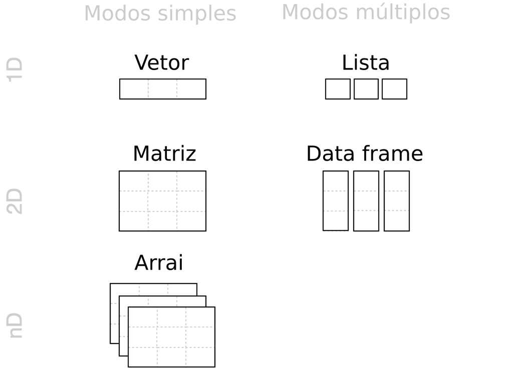

Estruturas de dados mais comuns de R: vetores, matrizes, arrays, listas e data frames. Adaptado de: Grolemund (2014).

#### Vetor

Há diversas formas de se **criar um vetor** no R:

1. Concatenando elementos com a função `c`
2. Criando sequências unitárias `:` ou com a função `seq()`
3. Criando repetições com a função `rep()`
4. “Colar” palavras com uma sequência numérica com a função `paste()` ou `paste0()`
5. Amostrando aleatoriamente elementos com a função `sample()`

```r
# concatenar elementos numericos
concatenar <- c(15, 18, 20, 22, 18)

# sequencia unitaria (x1:x2)
sequencia <- 1:10

# sequencia com diferentes espacamentos
sequencia_esp <- seq(from = 0, to = 100, by = 10)

# repeticao
repeticao <- rep(x = c(TRUE, FALSE), times = 5)

# cola palavra e sequencia numerica - sem separacao definida (" ")
colar <- paste("amostra", 1:5)

# amostragem aleatória - sem reposição
amostragem <- sample(1:100, 10)
```

Como os vetores são homogênios, i.e., só comportam um modo, quando combinamos mais de modo no mesmo objeto existe uma dominância de modos. Existe dessa forma uma **coerção** dos elementos combinados para todos fiquem iguais. Essa dominância segue essa ordem:

> **`DOMINANTE`** character >>> double >>> interger >>> logical **`RECESSIVO`**

Além disso, podemos utilizar as conversões listadas anteiormente para alterar os modos. Vamos exemplificar combinando os vetores criados anteriormente, e convertendo-os.

```r
# coercao
c(colar, amostragem)
```

```
##  [1] "amostra 1" "amostra 2" "amostra 3" "amostra 4" "amostra 5" "50"
##  [7] "62"        "42"        "71"        "75"        "47"        "55"
## [13] "23"        "58"        "84"
```

```r
# conversao
as.numeric(repeticao)
```

```
##  [1] 1 0 1 0 1 0 1 0 1 0
```

#### Fator

O **fator** representa medidas de uma **variável qualitativa**, podendo ser **nominal ou ordinal**. É fundamental destacar que fatores no R devem ser entendidos como um vetor de **interger**, i.e., ele é composto por números inteiros representando os níveis da variável categórica.

```r
# fatores nominal
fator_nominal <- factor(x = sample(c("floresta", "pastagem", "cerrado"), 20, replace = TRUE),
        levels = c("floresta", "pastagem", "cerrado"))

# fatores ordinal
fator_ordinal <- factor(x = sample(c("baixa", "media", "alta"), 20, replace = TRUE),
                        levels = c("baixa", "media", "alta"), ordered = TRUE)

# conversao
fator <- as.factor(x = sample(c("floresta", "pastagem", "cerrado"), 20, replace = TRUE))
```

#### Matriz

A **matrix** representa os dados no **formato de tabela**, com linhas e colunas. As linhas representam **unidades amostrais** (locais, transectos, parcelas) e as coluncas representam **variáveis quantitativas** (discretas ou contínuas) ou **descrições** (informações em texto).

Podemos **criar matrizes** no R de **duas formas** principais. A primeira delas **dispondo elementos de um vetor** em um certo número de linhas e colunas com a função `matrix()`, podendo preencher essa matriz com os elementos do vetor por linhas ou por colunas alterando o argumento **byrow**.

```r
# vetor
ve <- 1:12

# matrix - preenchimento por linhas - horizontal
ma_row <- matrix(data = ve, nrow = 4, ncol = 3, byrow = TRUE)

# matrix - preenchimento por colunas - vertical
ma_col <- matrix(data = ve, nrow = 4, ncol = 3, byrow = FALSE)
```

A segundo forma **combinando vetores**, utilizando a função `rbind` para combinar veores por linha, i.e., vetor embaixo do outro, e `cbind` para combinar vetores por coluna, i.e., vetor ao lado do outro.

```r
# criar dois vetores
vec_1 <- c(1, 2, 3)
vec_2 <- c(4, 5, 6)

# combinar por linhas - vertical - um embaixo do outro
ma_rbind <- rbind(vec_1, vec_2)

# combinar por colunas - horizontal - um ao lado do outro
ma_cbind <- cbind(vec_1, vec_2)
```

#### Arrai

O **arrai** representa **combinação de tabelas**, com linhas, colunas e dimensões. Essa combinação pode ser feita em múltiplas dimensões, mas apesar disso, geralmente é mais comum o uso em Ecologia para três dimensões, por exemplo: **linhas** (unidades amostrais), **colunas** (espécies) e **dimensão** (tempo). Isso gera um “cubo mágico”, onde podemos comparar, nesse caso, comunidades ao longo do tempo.

Podemos criar arrais no R **dispondo elementos de um vetor** em um certo **número de linhas, colunas e dimensões** com a função `array()`. Em nosso exemplo, vamos compor 10 comunidades de 20 espécies ao longo de cinco períodos.

```r
# arrai
ar <- array(data = sample(c(0, 1), 1e3, rep = TRUE),
            dim = c(10, 20, 5))
```

#### Data frame

O **data frame** representa dados no **formato de tabela**, com linhas e colunas, muito semelhante à matriz. Mas diferentemente das matrizes, os data frames comportam **mais de um modo** em suas colunas. Dessa forma, as linhas do data frame ainda representam **unidades amostrais** (locais, transectos, parcelas), mas as colunas agora podem representar **descrições** (informações em texto), **variáveis quantitativas** (discretas ou contínuas) e/ou **variáveis qualitativas** (nominais ou ordinais).

A forma mais simples de criar data frames no R é através da **combinação de vetores**. Essa combinação é feita com a função `data.frame()`, e ocorre de **forma horizontal**, semelhante à função `cbind()`. Sendo assim, todos os vetores precisam ter o mesmo **número de elementos**, ou seja, **mesmo comprimento**. Podemos ainda nomear as colunas para cada vetor.

```r
# criar tres vetores
vec_ch <- c("sp1", "sp2", "sp3")
vec_nu <- c(4, 5, 6)
vec_fa <- factor(c("campo", "floresta", "floresta"))

# data.frame - combinar por colunas - horizontal - um ao lado do outro
df <- data.frame(vec_ch, vec_nu, vec_fa)

# data.frame - nomear as colunas
df <- data.frame(especies = vec_ch,
                 abundancia = vec_nu,
                 vegetacao = vec_fa)
```

#### Lista

A **lista é tipo especial de vetor**, que aceita objetos como elementos. Ela é a estrutura de dados utilizada para **agrupar objetos**, e é geralmente a **saída de muitas funções** que fazem análises estatísticas.

Podemos criar listas através da função `list()`. Essa função funciona de forma semelhante à função `c()` para a criação de vetores, mas agora estamos concatenando elementos. Podemos ainda nomear os elementos que estamos combinando.

Um ponto interessante para entender **data frames**, é que eles são listas, em que todos os elementos (colunas) possuem o mesmo **número de elementos**, ou seja, **mesmo comprimento**.

```r
# lista
lista <- list(rep(1, 20), # vector
              factor(1, 1), # factor
              cbind(c(1, 2), c(1, 2))) # matrix

# lista - nomear os elementos
lista <- list(vector = rep(1, 20), # vector
              factor = factor(1, 1), # factor
              matrix = cbind(c(1, 2), c(1, 2))) # matrix
```

#### Funções

Uma última estrutura de objetos criados no R são as **funções**. Elas são objetos **criados pelo usuário** e **reutilizados** para fazer operações específicas. A criação de funções geralmente é um tópico tratado num segundo momento, quando o usuário de R adquire certo conhecimento da linguagem. Aqui abordarem apenas seu funcionamento básico, diferenciando sua estrutura para entendimento e sua diferenciação das demais estruturas. Vamos criar uma função simples que retorna a multiplicação de dois termos.

```r
# criar uma funcao
multi <- function(x, y){

  mu <- (x * y)
  return(mu)

}

# uso
multi(42, 42)
```

```
## [1] 1764
```

### Manipulação de objetos unidimensionais

Vamos agora explorar formas de **manipular elementos de objetos unidimensionais**, ou seja vetores, fatores e listas.

A primeira forma de manipulação é através da **indexação**, utilizando os operadores `[]`. Com a indexação podemos **acessar elementos** de vetores e fatores por **sua posição**. Iremos utilizar números, sequência de números ou operação booleanas para retornar partes dos vetores ou factores. Podemos ainda retirar elementos dos vetores com o operação aritmético `-`.

```r
# fixar a amostragem
set.seed(42)

# amostrar 10 elementos de uma sequencia
ve <- sample(seq(0, 2, .05), 10)
ve
```

```
##  [1] 1.80 0.00 1.20 0.45 1.75 0.85 1.15 0.30 1.90 0.20
```

```r
# seleciona o quinto elemento
ve[5]
```

```
## [1] 1.75
```

```r
# seleciona os elementos de 1 a 5
ve[1:5]
```

```
## [1] 1.80 0.00 1.20 0.45 1.75
```

```r
# retira o decimo elemento
ve[-10]
```

```
## [1] 1.80 0.00 1.20 0.45 1.75 0.85 1.15 0.30 1.90
```

```r
# retira os elementos 2 a 9
ve[-(2:9)]
```

```
## [1] 1.8 0.2
```

Podemos ainda fazer uma **seleção condicional** do vetor. Ao utilizarmos operadores relacionais, teremos como resposta um vetor lógico. Esse vetor lógico pode ser utilizado dentro da indexação para seleção de elementos.

```r
# quais valores sao maiores que 1?
ve > 1
```

```
##  [1]  TRUE FALSE  TRUE FALSE  TRUE FALSE  TRUE FALSE  TRUE FALSE
```

```r
# valores acima de 1
ve[ve > 1]
```

```
## [1] 1.80 1.20 1.75 1.15 1.90
```

Além da indexação, temos algumas **função que nos auxiliam em algumas operações com objetos unidimensionais** listadas na Tabela @ref(tab:tab-tab-funcoes-conf-uni).

Funções para verificação e resumo de dados unidimensionais.

| Função | Descrição |
| --- | --- |
| `max()` | Valor máximo |
| `min()` | Valor mínimo |
| `range()` | Amplitude |
| `length()` | Comprimento |
| `sum()` | Soma |
| `cumsum()` | Soma cumulativa |
| `prod()` | Produto |
| `sqrt()` | Raiz quadrada |
| `abs()` | Valor absoluto |
| `exp()` | Expoente |
| `log()` | Logaritmo natural |
| `log1p()` | Logaritmo natural mais 1 *log(x + 1)* |
| `log2()` | Logaritmo base 2 |
| `log10()` | Logaritmo base 10 |
| `mean()` | Média |
| `mean.weighted()` | Média ponderada |
| `var()` | Variância |
| `sd()` | Desvio Padrão |
| `mediam()` | Mediana |
| `quantile()` | Quantil |
| `quarters()` | Quartil |
| `round()` | Arredondamento |
| `sort()` | Ordenação |
| `order()` | Posição ordenada |
| `rev()` | Reverso |
| `unique()` | Únicos |
| `summary()` | Resumo estatístico |
| `cut()` | Divide variável contínua em fator |
| `pretty()` | Divide variável contínua em intervalos |
| `scale()` | Padronização e centralização |
| `sub()` | Substitui caracteres |
| `grep()` | Posição de caracteres |
| `any()` | Algum valor? |
| `all()` | Todos os valores? |
| `which()` | Quais valores? |
| `subset()` | Subconjunto |
| `ifelse()` | Operação condicional |

Para **listas**, também podemos usar a indexação `[]` para **acessar ou retirar elementos**.

```r
# lista
li <- list(elem1 = 1, elem2 = 2, elem3 = 3)

# acessar o primeiro elemento
li[1]
```

```
## $elem1
## [1] 1
```

```r
# retirar o primeiro elemento
li[-1]
```

```
## $elem2
## [1] 2
##
## $elem3
## [1] 3
```

Podemos ainda usar a indexação dupla `[[]]` para **acessar os valores dos elementos**.

```r
# acessar o valor do primeiro elemento
li[[1]]
```

```
## [1] 1
```

```r
# acessar o valor do segundo elemento
li[[2]]
```

```
## [1] 2
```

Para **listas nomeadas**, podemos ainda utilizar o operador `$` para acessar elementos pelo nome.

```r
# acessar o primeiro elemento
li$elem1
```

```
## [1] 1
```

E ainda podemos utilizar funções para medir o comprimento dessa lista, listar os nomes dos elementos ou ainda renomear os elementos: `length()` e `names()`.

```r
# comprimento
length(li)
```

```
## [1] 3
```

```r
# nomes
names(li)
```

```
## [1] "elem1" "elem2" "elem3"
```

```r
# renomear
names(li) <- paste0("elemento0", 1:3)
li
```

```
## $elemento01
## [1] 1
##
## $elemento02
## [1] 2
##
## $elemento03
## [1] 3
```

### Manipulação de objetos multidimensionais

Da mesma forma que para objetos unidimensionais, **manipular elementos de objetos multidimensionais**, ou seja matrizes, data frames e arrais.

Novamente, a primeira forma de manipulação é através da **indexação**, utilizando os operadores `[]`. Com a indexação podemos **acessar elementos** de matrizes, data frames e arrais por **sua posição**. Podemos ainda retirar elementos dos vetores com o operação aritmético `-`.

Entretanto, agora temos **mais de uma dimensão** na estruturação dos elementos dentro dos objetos. Assim, utilizamos números, sequência de números ou operação booleanas para retornar partes desses objetos, mas as dimensões têm de ser explicitadas, e separadas por **vírgulas**, i.e., para acessar linhas e colunas, listamos respectivamente números antes e depois da vírgula. Essa indexação funciona para matrizes e data frames. Para arrais, especificamos as dimensões também separadas por vírgulas para acessar outras dimensões.

```r
# matriz
ma <- matrix(1:12, 4, 3)
ma
```

```
##      [,1] [,2] [,3]
## [1,]    1    5    9
## [2,]    2    6   10
## [3,]    3    7   11
## [4,]    4    8   12
```

```r
ma[3, ] # linha 3
```

```
## [1]  3  7 11
```

```r
ma[, 2] # coluna 2
```

```
## [1] 5 6 7 8
```

```r
ma[1, 2] # elemento da linha 1 e coluna 2
```

```
## [1] 5
```

```r
ma[1, 1:2] # elementos da linha 1 e coluna 1 e 2
```

```
## [1] 1 5
```

```r
ma[1, c(1, 3)] # elementos da linha 1 e coluna 1 e 3
```

```
## [1] 1 9
```

Para data frames, além de utilizar **números e/ou sequências de numeros** dentro do operador `[]` simples, assim como podemos utilizar o operador `[[]]` duplo para retornar apenas o valores de uma colunas. Se as colunas **estiverem nomeadas**, podemos utilizar o nome da coluna de interesse entre aspas dentro dos operadores `[]` (retorna coluna) e `[[]]` (retorna apenas os valores), assim como ainda podemos utilizar o operador `$`. Essas últimas operações **retornam um vetor**, para o qual podemos fazer operações de vetores ou ainda **atualizar** o valor dessa coluna selecionada ou **adicionar** outra coluna.

```r
# criar tres vetores
sp <- paste("sp", 1:10, sep = "")
abu <- 1:10
flo <- factor(rep(c("campo", "floresta"), each = 5))

# data frame
df <- data.frame(sp, abu, flo)
df
```

```
##      sp abu      flo
## 1   sp1   1    campo
## 2   sp2   2    campo
## 3   sp3   3    campo
## 4   sp4   4    campo
## 5   sp5   5    campo
## 6   sp6   6 floresta
## 7   sp7   7 floresta
## 8   sp8   8 floresta
## 9   sp9   9 floresta
## 10 sp10  10 floresta
```

```r
# [] - numeros
df[, 1]
```

```
##  [1] "sp1"  "sp2"  "sp3"  "sp4"  "sp5"  "sp6"  "sp7"  "sp8"  "sp9"  "sp10"
```

```r
# [] - nome das colunas - retorna coluna
df["flo"]
```

```
##         flo
## 1     campo
## 2     campo
## 3     campo
## 4     campo
## 5     campo
## 6  floresta
## 7  floresta
## 8  floresta
## 9  floresta
## 10 floresta
```

```r
# [[]] - nome das colunas - retorna apenas os valores
df[["flo"]]
```

```
##  [1] campo    campo    campo    campo    campo    floresta floresta floresta
##  [9] floresta floresta
## Levels: campo floresta
```

```r
# $ funciona apenas para data frame
df$sp
```

```
##  [1] "sp1"  "sp2"  "sp3"  "sp4"  "sp5"  "sp6"  "sp7"  "sp8"  "sp9"  "sp10"
```

```r
# operacao de vetors
length(df$abu)
```

```
## [1] 10
```

```r
# converter colunas
df$abu <- as.character(df$abu)
mode(df$abu)
```

```
## [1] "character"
```

```r
# adicionar colunas
set.seed(42)
df$abu2 <- sample(0:1, nrow(df), rep = TRUE)

df
```

```
##      sp abu      flo abu2
## 1   sp1   1    campo    0
## 2   sp2   2    campo    0
## 3   sp3   3    campo    0
## 4   sp4   4    campo    0
## 5   sp5   5    campo    1
## 6   sp6   6 floresta    1
## 7   sp7   7 floresta    1
## 8   sp8   8 floresta    1
## 9   sp9   9 floresta    0
## 10 sp10  10 floresta    1
```

Podemos ainda fazer **seleções condicionais** para **retornar linhas** com valores que temos interesse, semelhante ao uso de filtro de uma planilha eletrônica.

```r
# selecionar linhas de uma matriz ou data frame
df[df$abu > 4, ]
```

```
##    sp abu      flo abu2
## 5 sp5   5    campo    1
## 6 sp6   6 floresta    1
## 7 sp7   7 floresta    1
## 8 sp8   8 floresta    1
## 9 sp9   9 floresta    0
```

```r
df[df$flo == "floresta", ]
```

```
##      sp abu      flo abu2
## 6   sp6   6 floresta    1
## 7   sp7   7 floresta    1
## 8   sp8   8 floresta    1
## 9   sp9   9 floresta    0
## 10 sp10  10 floresta    1
```

Além disso, há uma série de funções para conferência e manipulação de dados que listamos na Tabela @ref(tab:tab-funcoes-conf-multi).

Funções para verificação e resumo de dados multidimensionais.

| Função | Descrição |
| --- | --- |
| `head()` | Mostra as primeiras 6 linhas |
| `tail()` | Mostra as últimas 6 linhas |
| `nrow()` | Mostra o número de linhas |
| `ncol()` | Mostra o número de colunas |
| `dim()` | Mostra o número de linhas e de colunas |
| `rownames()` | Mostra os nomes das linhas (locais) |
| `colnames()` | Mostra os nomes das colunas (variáveis) |
| `str()` | Mostra as classes de cada coluna (estrutura) |
| `summary()` | Mostra um resumo dos valores de cada coluna |
| `rowSums()` | Calcula a soma das linhas (horizontal) |
| `colSums()` | Calcula a soma das colunas (vertical) |
| `rowMeans()` | Calcula a média das linhas (horizontal) |
| `colMeans()` | Calcula a média das colunas (vertical) |
| `str()` | Mostra a estrutura dos dados |
| `table()` | Tabulação cruzada |
| `t()` | Matriz ou data frame transposto |

### Valores faltantes e especiais

**Valores faltantes e especiais** são **valores reservados** que representam dados faltantes, indefinições matemáticas, infinitos e objetos nulos.

1. **NA (*Not Available*)**: significa dado faltante/indisponível
2. **NaN (*Not a Number*)**: representa indefinições matemáticas
3. **Inf (*Infinito*)**: é um número muito grande ou um limite matemático
4. **NULL *(Nulo*)**: representa um objeto nulo, sendo útil para preenchimento de laços e outras aplicações de programação

```r
# data frame com elemento NA
df <- data.frame(var1 = c(1, 4, 2, NA), var2 = c(1, 4, 5, 2))
df
```

```
##   var1 var2
## 1    1    1
## 2    4    4
## 3    2    5
## 4   NA    2
```

```r
# resposta booleana para elementos na
is.na(df)
```

```
##       var1  var2
## [1,] FALSE FALSE
## [2,] FALSE FALSE
## [3,] FALSE FALSE
## [4,]  TRUE FALSE
```

```r
# algum elemento é na?
any(is.na(df))
```

```
## [1] TRUE
```

```r
# remover as linhas com nas
df_sem_na <- na.omit(df)
df_sem_na
```

```
##   var1 var2
## 1    1    1
## 2    4    4
## 3    2    5
```

```r
# substituir nas por 0
df[is.na(df)] <- 0
df
```

```
##   var1 var2
## 1    1    1
## 2    4    4
## 3    2    5
## 4    0    2
```

```r
# nan - not a number
0/0
```

```
## [1] NaN
```

```r
log(-1)
```

```
## [1] NaN
```

```r
# limite matematico
1/0
```

```
## [1] Inf
```

```r
# numero grande
10^310
```

```
## [1] Inf
```

```r
# objeto nulo
nulo <- NULL
nulo
```

### Diretório de trabalho

O diretório de trabalho é o **endereço da pasta (ou diretório)** de onde o R irá **importar ou exportar** os nossos dados.

Podemos utilizar o próprio RStudio para tal tarefa, indo em Session > Set Work Directory > Choose Directory…, ou simplesmente utilizar o atalho `ctrl + shift + H`.

Podemos ainda utilizar as funções do R para definir o diretório. Para tanto, podemos navegar com o aplicativo de gerenciador de arquivos (e.g. Windows Explorer) até nosso diretório de interesse, e copiar o endereço na barra superior. Voltamos para o R e colamos esse endereço entre aspas como um argumento da função `setwd()`. É fundamental destacar que em Sistemas Operacionais Windows é necessário inverter as barras (`\` por `/`).

Aconselhamos ainda utilizar as funções `getwd()` para retornar o diretório definido na sessão do R, assim como as funções `dir()` ou `list.files()` para listagem dos arquivos no diretório, ambas medidas de conferência do diretório correto.

```r
# definir o diretorio de trabalho
setwd("/home/mude/data/github/livro_r_ecologia/dados")

# verificar o diretorio
getwd()

# listar os arquivos no diretorio
dir()
list.files()
```

### Importar dados

Uma das operações mais corriqueiras do R, antes de realizar alguma análise, é a de **importar dados** que foram **tabulados numa planilha eletrônica** e salvos no formato .csv, .txt ou .xlsx. Ao importar esse tipo de dado para o R, o formato que o mesmo assume, se nenhum parâmetro for especificado, é o da classes `dataframe`, prevendo que a planilha de dados possua colunas com diferentes modos.

Existe diversas formas de importar dados para o R. Podemos importar utilizando o RStudio, indo na janela **Environment** (Figura @ref(fig:fig-rstudio) (3)) e clicar em “Importar Dataset”.

Entretanto, aconselhamos o **uso de funções** que fiquem salvas em um script para aumentar a reprodutibilidade do script. Dessa forma, as **três principais funções** para importar os arquivos nos **três principais extensões** (.csv, .txt ou .xlsx) são, respectivamente: `read.csv()`, `read.table()` e `openxlsx::read.xlsx()``, sendo o último do pacote *openxlsx*.

```r
# instalar pacote openxlsx
install.packages("openxlsx")
library(openxlsx)
```

Para exemplificar como importar dados, vamos usar os dados de **comunidades de anfíbios da Mata Atlântica** (Atlantic Amphibians, Vancine et al. 2018). Iremos fazer o download diretamente do site da fonte dos dados.

Antes vamos antes escolher um diretório de trabalho com a função `setwd()`, e em seguida criar um diretório com a função `dir.create()` chamado “dados”. Em seguida, vamos mudar nosso diretóri para essa pasta, e criar mais um diretório chamado “tabelas”, e definir esse diretório para fazer o download.

```r
# escolher um diretorio
setwd("/home/mude/data/github/livro_r_ecologia")

# criar um diretorio 'dados'
dir.create("dados")

# escolher diretorio 'dados'
setwd("dados")

# criar um diretorio 'tabelas'
dir.create("tabelas")

# escolher diretorio 'tabelas'
setwd("tabelas")
```

Agora podemos fazer o download de um arquivo `.zip` e extrair as tabelas usando a função `unzip()` nesse mesmo diretório.

```r
# download
download.file(url = "https://esajournals.onlinelibrary.wiley.com/action/downloadSupplement?doi=10.1002%2Fecy.2392&file=ecy2392-sup-0001-DataS1.zip",
       destfile = "atlantic_amphibians.zip", mode = "wb")

# unzip
unzip(zipfile = "atlantic_amphibians.zip")
```

Agora podemos importar a tabela de dados com a função `read.csv()`, atribuindo ao objeto `aa_locais`.

```r
# importar tabela de locais
aa_locais <- read.csv("dados/tabelas/ATLANTIC_AMPHIBIANS_sites.csv")
```

Esse arquivo foi criado com separador de decimais sendo `.` e separador de colunas sendo `,`. Caso tivesse sido criado com separador de decimais sendo `,` e separador de colunas sendo `;`, usaríamos a função `read.csv2()`.

### Conferência de dados importados

Uma vez importados os dados para o R, geralmente antes de inicarmos qualquer manejo, visualização ou análise de dados, fazemos a **conferência desses dados**. Para isso, podemos utilizar as funções listadas na Tabela @ref(tab:tab-funcoes-conf-multi).

```r
# primeiras linhas
head(aa_locais)
```

```
##        id reference_number species_number record sampled_habitat active_methods
## 1 amp1001             1001             19     ab           fo,ll             as
## 2 amp1002             1002             16     co        fo,la,ll             as
## 3 amp1003             1002             14     co        fo,la,ll             as
## 4 amp1004             1002             13     co        fo,la,ll             as
## 5 amp1005             1003             30     co        fo,ll,br             as
## 6 amp1006             1004             42     co  tp,pp,la,ll,is           <NA>
##   passive_methods complementary_methods      period month_start year_start
## 1              pt                  <NA> mo,da,tw,ni           9       2000
## 2              pt                  <NA> mo,da,tw,ni          12       2007
## 3              pt                  <NA> mo,da,tw,ni          12       2007
## 4              pt                  <NA> mo,da,tw,ni          12       2007
## 5            <NA>                  <NA>    mo,da,ni           7       1988
## 6            <NA>                  <NA>        <NA>          NA         NA
##   month_finish year_finish effort_months country    state state_abbreviation
```

[output cut: 20 more lines]

```r
# ultimas linhas
tail(aa_locais)
```

```
##           id reference_number species_number record sampled_habitat
## 1158 amp2158             1389              3     co            <NA>
## 1159 amp2159             1389              9     co            <NA>
## 1160 amp2160             1389              6     co            <NA>
## 1161 amp2161             1389              1     co            <NA>
## 1162 amp2162             1389              2     co            <NA>
## 1163 amp2163             1389              2     co            <NA>
##      active_methods passive_methods complementary_methods period month_start
## 1158           <NA>            <NA>                  <NA>   <NA>          NA
## 1159           <NA>            <NA>                  <NA>   <NA>          NA
## 1160           <NA>            <NA>                  <NA>   <NA>          NA
## 1161           <NA>            <NA>                  <NA>   <NA>          NA
## 1162           <NA>            <NA>                  <NA>   <NA>          NA
## 1163           <NA>            <NA>                  <NA>   <NA>          NA
##      year_start month_finish year_finish effort_months   country    state
```

[output cut: 27 more lines]

```r
# numero de linhas e colunas
nrow(aa_locais)
```

```
## [1] 1163
```

```r
ncol(aa_locais)
```

```
## [1] 25
```

```r
dim(aa_locais)
```

```
## [1] 1163   25
```

```r
# nome das linhas e colunas
rownames(aa_locais)
colnames(aa_locais)

# estrutura dos dados
str(aa_locais)

# resumo dos dados
summary(aa_locais)

# verificar nas
any(is.na(aa_locais))
which(is.na(aa_locais))

# remover as linhas com nas
aa_locais_na <- na.omit(aa_locais)
```

### Exportar dados

Uma vez realizado as operações de manipulações ou tendo dados que foram analisados e guardados num objeto no formato de data frame ou matriz, podemos **exportar esses dados** do R para o diretório que definimos anteriormente.

Para tanto, podemos utilizar funções de **escrita de dados**, como `write.csv()`, `write.table()` e `openxlsx::write.xlsx()`. Dois pontos são fundamentais: 1. o nome do arquivo tem de estar entre aspas e no final dele deve constar a extensão que pretende que o arquivo tenha; 2. é interessante utilizar os argumentos **row.names = FALSE** e **quote**, para que o arquivo escrito não tenha o nome das linhas ou aspas em todas as células.

```r
# exportar dados na extensao .csv
write.csv(aa_locais_na, "ATLANTIC_AMPHIBIAN_sites_na.csv",
     row.names = FALSE, quote = FALSE)

# exportar dados na extensao .txt
write.table(aa_locais_na, "ATLANTIC_AMPHIBIAN_sites_na.txt",
      row.names = FALSE, quote = FALSE)


# exportar dados na extensao .xlsx
openxlsx::write.xlsx(aa_locais_na, "ATLANTIC_AMPHIBIAN_sites_na.xlsx",
           row.names = FALSE, quote = FALSE)
```

## Tidyverse

### Contextualização

Como todo idioma, a linguagem R vem passando por transformações nos últimos anos. Grande parte dessas mudanças estão dentro do paradigma da **Ciência de Dados (*Data Science*)**, uma nova área de conhecimento que vem se moldando acompanhando o desenvolvimento da sociedade em torno da era digital e da grande quantidade de dados gerados e disponíveis pela internet e computação, de onde advém os pilares das inovações tecnológicas: *Big Data*, *Machine Learning*, e *Internet of Things*.

A grande necessidade de computação parapara desenvolver essa nova abordagem, colocaram o **R e o Python** como as **principais linguagens de programação** frente à esses novos desafios. Apesar de não serem as únicas utilizadas para esses propósitos, elas rapidamente se tornaram uma das **melhores escolhas**, dado vários fatores como: serem livres, possuir comunidade ativa, grande e contribuidora, serem linguagens de interpretação (orientadas à objeto), e relativamente fáceis de serem aprendidas.

À partir dessas ideias, o [*tidyverse*](https://www.tidyverse.org/) foi operacionalizado no R como uma coleção de pacotes R que atuam no **workflow comum da ciência de dados**: importação, manipulação, exploração, visualização, análise e comunicação de dados e análises (Wickhan et al. 2019) (Figura @ref(fig:fig-r-tidyverse)). O principal objetivo do **Tidyverse** é aproximar a linguagem para melhorar a interação entre ser humano e computador sobre dados, de modo que os pacotes compartilham uma filosofia de design de alto nível e gramática, além da estrutura de dados de baixo nível (Wickhan et al. 2019).

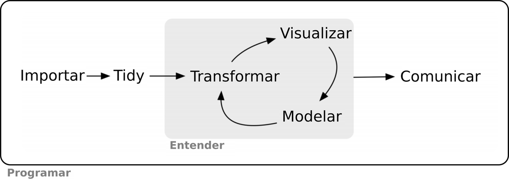

Modelo das ferramentas necessárias em um projeto típico de ciência de dados: importar, organizar, entender (transformar, visualizar, modelar) e comunicar, envolto à essas ferramentas está a programação. Adaptado de: Wickhan & Grolemund (2017).

As principais leituras sobre o tema no R são os artigos Wickham (2014), Wickham et al. (2019), o livro Wickhan & Grolemund (2017), disponível on-line neste [link](https://r4ds.had.co.nz/), além do [site](https://www.tidyverse.org/) que possui muito mais informações.

### *tidyverse*

Uma vez instalado e carregado, o pacote tidyverse **disponibiliza um conjunto de ferramentas** através de vários pacotes. Esses pacotes **compartilham** uma filosofia de design, gramática e estruturas de dados. Podemos entender o *tidyverse* como um “dialeto novo” para a linguagem R, onde **tidy** quer dizer organizado, arrumado, ordenado, e **verse** é universo.

- [*readr*](https://readr.tidyverse.org/): importa dados tabulares (.csv e .txt)
- [*tibble*](https://tibble.tidyverse.org/): implementou o “tibble”, com melhorias na classe `dataframe`
- [*tidyr*](https://tidyr.tidyverse.org/): facilita a transformação de dados para *tidy*
- [*dplyr*](https://dplyr.tidyverse.org/): facilita a manipulação de dados
- [*stringr*](https://github.com/tidyverse/stringr): facilita a manipulação de caracteres
- [*forcats*](https://github.com/hadley/forcats): facilita a manipulação de fatores
- [*ggplot2*](https://ggplot2.tidyverse.org/): visualização de dados
- [*purrr*](https://purrr.tidyverse.org/): programação funcional

Além desses principais, fazemos a menção de **outros pacotes que estão dentro dessa aborgagem**, e que trataremos ainda neste capítulo, em outro momento do livro, ou que você leitor deve se familiarizar.

- [*readxl*](https://readxl.tidyverse.org/) e [*writexl*](https://cran.r-project.org/package=writexl): importa e exporta dados tabulares (.xlsx)
- [*DBI*](https://github.com/rstats-db/DBI): interface de banco de dados R
- [*haven*](https://github.com/tidyverse/haven): importa e exporta dados do SPSS, Stata e SAS
- [*httr*](https://github.com/r-lib/httr): ferramentas para trabalhar com URLs e HTTP
- [*rvest*](https://github.com/tidyverse/rvest): coletar facilmente (raspe) páginas da web
- [*xml2*](https://github.com/r-lib/xml2): trabalhar com arquivos XML
- [*jsonlite*](https://github.com/jeroen/jsonlite): um analisador e gerador JSON simples e robusto para R
- [*hms*](https://github.com/rstats-db/hms): hora do dia
- [*lubridate*](https://github.com/tidyverse/lubridate): facilita o tratamento de datas
- [*magrittr*](https://magrittr.tidyverse.org/): provê os operadores pipe (`%>%`, `%$%`, `%<>%`)
- [*glue*](https://github.com/tidyverse/glue): facilita combinar dados e caracteres
- [*rmarkdown*](https://rmarkdown.rstudio.com/): cria documentos de análise dinâmica que combinam código, saída renderizada (como figuras) e texto
- [*knitr*](https://yihui.org/knitr/): projetado para ser um mecanismo transparente para geração de relatórios dinâmicos com R
- [*shiny*](https://shiny.rstudio.com/): framework de aplicativo Web para R
- [*flexdashboard*](https://rmarkdown.rstudio.com/flexdashboard/): painéis interativos para R
- [*here*](https://here.r-lib.org/): facilita a definição de diretórios
- [*usethis*](https://usethis.r-lib.org/): automatiza tarefas durante a configuração e desenvolvimento de projetos (Git, ‘GitHub’ e Projetos RStudio)
- [*data.table*](https://rdatatable.gitlab.io/data.table/): pacote que fornece uma versão de alto desempenho do `data.frame` (importar, manipular e expotar)
- [*reticulate*](https://rstudio.github.io/reticulate/): pacote que fornece ferramentas para integrar Python e R
- [*sparklyr*](https://spark.rstudio.com/): interface R para Apache Spark
- [*broom*](https://github.com/tidymodels/broom): converte objetos estatísticos em tibbles organizados
- [*modelr*](https://github.com/tidyverse/modelr): funções de modelagem que funcionam com o pipe
- [*tidymodels*](https://www.tidymodels.org/): coleção de pacotes para modelagem e aprendizado de máquina usando os princípios do tidyverse

Para instalar os pacotes do *tidyverse*, rode o comando abaixo:

```r
# instalar o pacote tidyverse
install.packages("tidyverse")
```

Quando carregamos o pacote *tidyverse*, notamos uma mensagem indicando quais pacotes foram carregados, suas repectivas versões e os conflitos com outros pacotes.

```r
# carregar o pacote tidyverse
library(tidyverse)
```

Podemos ainda **listar todos os pacotes** do **tidyverse** com a função `tidyverse::tidyverse_packages()`.

```r
# listar todos os pacotes no tidyverse
tidyverse::tidyverse_packages()
```

```
##  [1] "broom"      "cli"        "crayon"     "dbplyr"     "dplyr"
##  [6] "forcats"    "ggplot2"    "haven"      "hms"        "httr"
## [11] "jsonlite"   "lubridate"  "magrittr"   "modelr"     "pillar"
## [16] "purrr"      "readr"      "readxl"     "reprex"     "rlang"
## [21] "rstudioapi" "rvest"      "stringr"    "tibble"     "tidyr"
## [26] "xml2"       "tidyverse"
```

Também podemos **verificar os pacotes para serem atualizados** com a função `tidyverse::tidyverse_update()`.

```r
# listar e atualizar os pacotes no tidyverse
tidyverse::tidyverse_update()
```

```
## All tidyverse packages up-to-date
```

Todas as funções dos pacotes tidyverse usão **fonte minúscula** e **usam `_` (*underscore*)** para separar os nomes internos das funções, seguindo a mesma sintaxe do Python (“Snake Case”). Neste sentido de padronização, é importante destacar ainda que existe um guia próprio para que os scripts sigam a recomendação de padronização, o [The tidyverse style guide](https://style.tidyverse.org/), criado pelo Hadley Wickham. Para os desenvolvedores, existe o [Tidyverse design guide](https://design.tidyverse.org/) criado pelo *Tidyverse team*.

```r
# funcoes no formato snake_case
read_csv()
read_xlsx()
as_tibble()
left_join()
group_by()
```

Por fim, para evitar possíveis **conflitos de funções com o mesmo nome entre pacotes**, recomendamos fortemente o hábito de usar as funções seguido do operador `::`. Assim, garante-se que a **função utilizada é referente ao pacote daquela função**. Segue um exemplo com as funções apresentadas anteriormente.

```r
# funcoes seguidas de seus respectivos pacotes
readr::read_csv()
readxl::read_xlsx()
tibble::as_tibble()
dplyr::left_join()
dplyr::group_by()
```

Seguindo essas ideias de organização de dados, outro conjunto de pacotes foi desenvolvido, chamado de [*tidymodels*](https://www.tidymodels.org/) que atuam no **workflow da análise de dados** em ciência de dados: separação e reamostragem, pre-processamento, ajuste de modelos e métricas de performace de ajustes. Por razões de espaço e especificidade, não entraremos em detalhes dessa abordagem.

Seguindo o workflow da Figura @ref(fig:fig-r-tidyverse), iremos ver nos itens das próximas seções como esses passos são realizados com funções de cada pacote.

### here

Seu uso é relativamente simples: uma vez criado e aberto o RStudio pelo **Projeto do RStudio**, o diretório automaticamente é definido para o diretório do projeto. Depois disso, podemos usar a função `here::here()` para definir os subdiretórios onde estão os dados. O exemplo da aplicação fica para a seção seguinte, quando iremos de fato importar um arquivo para o R. Logo abaixo, mostramos como instalar e carregar o pacote *here*.

```r
# instalar
install.packages("here")

# carregar
library(here)
```

### readr, readxl e writexl

Dado que possuímos um conjuntos de dados e que geralmente esse conjunto de dados estará no formato tabular com umas das extensões: .csv, .txt ou .xlsx, iremos usar o pacote *readr* ou *readxl* para importar esses dados para o R.

Esses pacotes **leem e escrevem grandes arquivos de forma mais rápida**, além de fornecem **medidores de progresso** de importação e exportação, e imprimir a **informação dos modos das colunas** quando faz a importação. Outro ponto bastante positivo, é que também **classificam automaticamente** o modo dos dados de cada coluna, i.e., se uma coluna possui dados numéricos ou apenas texto, essa informação será considerada para classificar a coluna toda. A **classe do objeto** atribuído quando lido por esses pacotes é automaticamente um “tibble”, que veremos melhor na seção seguinte.

Todas as funções deste pacote são listadas na [página de referência](https://readr.tidyverse.org/reference/index.html) do pacote.

Usamos as funções `readr::read_csv()` e `readr::write_csv()` para importar e exportar arquivos .csv do R, respectivamente. Para dados com a extensão .txt, podemos utilizar as funções `readr::read_tsv()` ou ainda `readr::read_delim()`. Para arquivos tabulares com a extensão .xlsx, temos de instalar dois pacotes adicionais: *readxl* e *writexl*, dos quais usaremos as funções `readxl::read_excel()`, `readxl::read_xlsx()` ou `readxl::read_xls()` para importar dados, atentado para o data de podermos indicar a aba com os dados com o argumento **sheet**, e `writexl::write_xlsx()` para exportar.

Se o arquivo .csv foi criado com separador de decimais sendo `.` e separador de colunas sendo `,`, usamos as funções normalmente. Caso tivesse sido criado com separador de decimais sendo `,` e separador de colunas sendo `;`, usaríamos as funções dessa forma: `readr::read_csv2()`.

```r
# importar lugares
aa_locais <- readr::read_csv(
  here::here("dados", "tabelas", "ATLANTIC_AMPHIBIANS_sites.csv")
  )
```

Para se aprofundar no tema, recomendamos a leitura do capítulo [11 Data import](https://r4ds.had.co.nz/data-import.html) de Wickhan & Grolemund (2017).

### tibble

O **tibble** (`tbl_sf`) é uma **versão aprimorada** do data frame (`data.frame`). Ele é a **classe aconselhada** para que as funções do tidyverse funcionem melhor sobre conjuntos de dados tabulares importados para o R.

Geralmente, quando utilizamos **funções tidyverse para importar dados para o R**, é essa classe que esses dados adquirem depois de importados. Além da importação de dados, podemos **criar** um tibble no R usando a função `tibble::tibble()`, semelhante ao uso da função `data.frame()`. Podemos ainda **converter** um `data.frame` para um `tibble` usando a função `tibble::as_tibble()`. Entretanto, em alguns momentos precisaremos da classe `data.frame` para algumas funções específicas, e podemos **converter** um `tibble` para `data.frame` usa-se a função `tibble::as_data_frame()`.

Existem **duas diferenças principais** no uso do `tibble` e do `data.frame`: impressão e subconjunto. Objetos da classe `tibbles` possuem um método de impressão que mostra a **contagem do número de linhas e colunas**, e apenas as **primeiras 10 linhas** e **todas as colunas** que cabem na tela no console, além dos **modos ou tipos das colunas**. Dessa forma, cada coluna ou variável, pode ser do modo numbers (`int` ou `dbl`), character (`chr`), logical (`lgl`), factor (`fctr`), date + time (`dttm`) date e (`date`), além de outras [inúmeras possibilidades](https://tibble.tidyverse.org/articles/types.html).

Todas as funções deste pacote são listadas na [página de referência](https://tibble.tidyverse.org/reference/index.html) do pacote.

```r
# tibble - impressao
aa_locais
```

```
## # A tibble: 1,163 x 25
##    id      reference_number species_number record sampled_habitat active_methods
##    <chr>              <dbl>          <dbl> <chr>  <chr>           <chr>
##  1 amp1001             1001             19 ab     fo,ll           as
##  2 amp1002             1002             16 co     fo,la,ll        as
##  3 amp1003             1002             14 co     fo,la,ll        as
##  4 amp1004             1002             13 co     fo,la,ll        as
##  5 amp1005             1003             30 co     fo,ll,br        as
##  6 amp1006             1004             42 co     tp,pp,la,ll,is  <NA>
##  7 amp1007             1005             23 co     sp              as
##  8 amp1008             1005             19 co     sp,la,sw        as,sb,tr
##  9 amp1009             1005             13 ab     fo              <NA>
## 10 amp1010             1006              1 ab     fo              <NA>
## # … with 1,153 more rows, and 19 more variables: passive_methods <chr>,
## #   complementary_methods <chr>, period <chr>, month_start <dbl>,
## #   year_start <dbl>, month_finish <dbl>, year_finish <dbl>,
## #   effort_months <dbl>, country <chr>, state <chr>, state_abbreviation <chr>,
## #   municipality <chr>, site <chr>, latitude <dbl>, longitude <dbl>,
## #   coordinate_precision <chr>, altitude <dbl>, temperature <dbl>,
## #   precipitation <dbl>
```

Para o subconjunto, como vimos anteriormente, para **selecionar colunas e linhas** de objetos bidimensionais podemos utilizar o operador `[]` ou `[[]]` associado com números separados por vírgulas ou o nome da coluna entre aspas, e o operador `$` para extrair pelo nome da coluna. Comparando um `data.frame` a um `tibbles`, esses últimos são mais rígidos: eles nunca fazem **correspondência parcial** e irão **gerar um aviso** se a coluna que você está tentando acessar não existir.

```r
# tibble - subconjunto
aa_locais$ref
```

```
## Warning: Unknown or uninitialised column: `ref`.
```

Por fim, podemos **“espiar” os dados** utilizando a função `tibble::glimpse()` para ter uma noção geral de número de linhas, colunas, e conteúdo de todas as colunas. Essa é função tidyverse da função R Base `str()`.

```r
tibble::glimpse(aa_locais[, 1:10])
```

```
## Rows: 1,163
## Columns: 10
## $ id                    <chr> "amp1001", "amp1002", "amp1003", "amp1004", "amp…
## $ reference_number      <dbl> 1001, 1002, 1002, 1002, 1003, 1004, 1005, 1005, …
## $ species_number        <dbl> 19, 16, 14, 13, 30, 42, 23, 19, 13, 1, 1, 2, 4, …
## $ record                <chr> "ab", "co", "co", "co", "co", "co", "co", "co", …
## $ sampled_habitat       <chr> "fo,ll", "fo,la,ll", "fo,la,ll", "fo,la,ll", "fo…
## $ active_methods        <chr> "as", "as", "as", "as", "as", NA, "as", "as,sb,t…
## $ passive_methods       <chr> "pt", "pt", "pt", "pt", NA, NA, NA, NA, "pt", "p…
## $ complementary_methods <chr> NA, NA, NA, NA, NA, NA, NA, NA, NA, NA, NA, NA, …
## $ period                <chr> "mo,da,tw,ni", "mo,da,tw,ni", "mo,da,tw,ni", "mo…
## $ month_start           <dbl> 9, 12, 12, 12, 7, NA, 4, 4, 4, 5, 5, 5, 5, 5, 5,…
```

Para se aprofundar no tema, recomendamos a leitura do capítulo [10 Tibbles](https://r4ds.had.co.nz/tibbles.html) de Wickhan & Grolemund (2017).

### magrittr (pipe - %>%)

O operador pipe `%>%` permite o **encadeamento de várias funções**, eliminando a necessidade de criar objetos para armazenar resultados intermediários. Dessa forma, pipes são uma **ferramenta poderosa** para expressar uma **sequência de múltiplas operações**.

O operador pipe `%>%` vem do pacote *magrittr*, entretanto, todos os pacotes no tidyverse automaticamente tornam o pipe disponível. Essa função torna os **códigos em R mais simples**, pois realizamos múltiplas operações em uma única linha. Ele **captura o resultado de uma declaração** e o **torna a entrada da próxima declaração**, então podemos pensar como “EM SEGUIDA FAÇA” ao final de cada linha de código.

Todas as funções deste pacote são listadas na [página de referência](https://maggritr.tidyverse.org/reference/index.html) do pacote.

A principal vantagem do uso dos pipes é facilitar o **debuging** (achar erros) nos códigos, porque seu uso torna a **linguagem R mais próxima do que falamos e pensamos**, uma vez que evita o uso de funções dentro de funções (funções compostas).

Digitar `%>%` é um pouco chato, dessa forma, existe um atalho para sua inserção nos scripts: `ctrl + shift + M`.

Para deixar esse tópico **menos estranho** à quem está vendo esse operação pela primeira vez, vamos fazer **alguns exemplos**.

```r
# base r - sem pipe
sqrt(sum(1:100))
```

```
## [1] 71.06335
```

```r
# tidyverse - com pipe
1:100 %>%
  sum() %>%
  sqrt()
```

```
## [1] 71.06335
```

Essas operações ainda estão simples, vamos complicá-las com várias funções compostas. É nesses casos que a **propriedade orgazacional** do uso do pipe emerge: podemos facilmente ver o **encadeamento de operações**, onde cada função é organizada numa linha.

```r
# fixar amostragem
set.seed(42)

# base r - sem pipe
ve <- sum(sqrt(sort(log10(rpois(100, 10)))))
ve
```

```
## [1] 99.91426
```

```r
# fixar amostragem
set.seed(42)

# tidyverse - com pipe
ve <- rpois(100, 10) %>%
  log10() %>%
  sort() %>%
  sqrt() %>%
  sum()
ve
```

```
## [1] 99.91426
```

O uso do pipe vai se **tornar especialmente útil** quando seguirmos para os pacotes das próximas duas seções: *tidyr* e *dplyr*. Com esses pacotes iremos fazer operações em linhas e colunas de nossos dados tabulares, então podemos **encademar uma série de funções** para manipulação, limpeza e análise de dados.

Há ainda **três outras variações do pipe** que podem ser úteis em alguns momentos, mas que para funcionar precisam que o pacote *magrittr* seja carregado:

- `%T>%`: retorna o lado esquerdo em vez do lado direito
- `%$%`: “explode” as variáveis em um quadro de dados
- `%<>%`: permite atribuição usando pipes

Para se aprofundar no tema, recomendamos a leitura do capítulo [18 Pipes](https://r4ds.had.co.nz/pipes.html) de Wickhan & Grolemund (2017).

### tidyr

Os conjuntos de **dados tidy** (organizados) são mais fáceis de manipular, modelar e visualizar. Um conjunto de dados está arrumado ou não, dependendo de como linhas, colunas e células são combinadas com observações, variáveis e valores. Nos **dados tidy**, as **variáveis estão nas colunas**, **observações estão nas linhas** e **valores estão nas células**, sendo que para esse último, não deve haver mais de um valor por célula (Figura @ref(fig:fig-r-dados-tidy)).

1. Cada variável em uma coluna
2. Cada observação em uma linha
3. Cada valor como uma célula

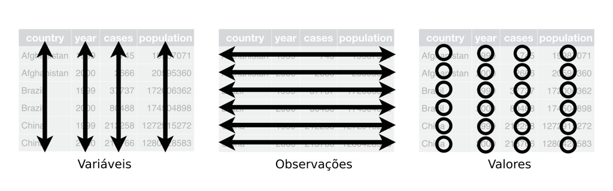

As três regras que tornam um conjunto de dados *tidy*. Adaptado de: Wickhan & Grolemund (2017).

Todas as funções deste pacote são listadas na [página de referência](https://tidyr.tidyverse.org/reference/index.html) do pacote.

Para realizar **diversas transformações nos dados** a fim de ajustá-los ao formato **tidy**, existe uma série de funções, para diversas finalidades: unir e separar, valores faltantes (`NA`), e pivotar (formato **longo** para **largo**), além de outras [funções específicas](https://tidyr.tidyverse.org/reference/index.html).

- `unite()`: junta dados de múltiplas colunas em uma coluna
- `separate()`: separa caracteres em múlplica colunas
- `separate_rows()`: separa caracteres em múlplica colunas e linhas
- `drop_na()`: retira linhas com `NA` do conjunto de dados
- `replace_na()`: substitui `NA` do conjunto de dados
- `pivot_wider()`: transformar conjunto de dados **longo** (*long*) para **largo** (*wide*)
- `pivot_longer()`: transformar conjunto de dados **largo** (*wide*) para **longo** (*long*)

Para exemplicar o funcionamento dessas funções, usaremos os dados de medidas de pinguins chamados [**palmerpenguins**](https://allisonhorst.github.io/palmerpenguins). Esses dados estão disponíveis no pacote *palmerpenguins*.

```r
# instalar o pacote
install.packages("palmerpenguins")
```

Esses dados foram coletados e disponibilizados pela [Dra. Kristen Gorman](https://www.uaf.edu/cfos/people/faculty/detail/kristen-gorman.php) e pela [Palmer Station, Antarctica LTER](https://pal.lternet.edu/), membro da Long Term Ecological Research Network.

O pacote *palmerpenguins* contém dois conjuntos de dados. Um é chamado de **penguins** e é uma versão simplificada dos dados brutos. O segundo conjunto de dados é **penguins_raw** e contém todas as variáveis e nomes originais baixados. Ambos os conjuntos de dados contêm dados para 344 pinguins, de três espécies diferentes, coletados em três ilhas no arquipélago de Palmer, na Antártica.

```r
# carregar o pacote palmerpenguins
library(palmerpenguins)

# ajuda dos dados
?penguins
?penguins_raw
```

```r
# visualizar os dados
penguins_raw
```

```
## # A tibble: 344 x 17
##    studyName `Sample Number` Species       Region Island Stage   `Individual ID`
##    <chr>               <dbl> <chr>         <chr>  <chr>  <chr>   <chr>
##  1 PAL0708                 1 Adelie Pengu… Anvers Torge… Adult,… N1A1
##  2 PAL0708                 2 Adelie Pengu… Anvers Torge… Adult,… N1A2
##  3 PAL0708                 3 Adelie Pengu… Anvers Torge… Adult,… N2A1
##  4 PAL0708                 4 Adelie Pengu… Anvers Torge… Adult,… N2A2
##  5 PAL0708                 5 Adelie Pengu… Anvers Torge… Adult,… N3A1
##  6 PAL0708                 6 Adelie Pengu… Anvers Torge… Adult,… N3A2
##  7 PAL0708                 7 Adelie Pengu… Anvers Torge… Adult,… N4A1
##  8 PAL0708                 8 Adelie Pengu… Anvers Torge… Adult,… N4A2
##  9 PAL0708                 9 Adelie Pengu… Anvers Torge… Adult,… N5A1
## 10 PAL0708                10 Adelie Pengu… Anvers Torge… Adult,… N5A2
## # … with 334 more rows, and 10 more variables: Clutch Completion <chr>,
## #   Date Egg <date>, Culmen Length (mm) <dbl>, Culmen Depth (mm) <dbl>,
## #   Flipper Length (mm) <dbl>, Body Mass (g) <dbl>, Sex <chr>,
## #   Delta 15 N (o/oo) <dbl>, Delta 13 C (o/oo) <dbl>, Comments <chr>
```

```r
# espiar os dados
tibble::glimpse(penguins_raw)
```

```
## Rows: 344
## Columns: 17
## $ studyName             <chr> "PAL0708", "PAL0708", "PAL0708", "PAL0708", "PAL…
## $ `Sample Number`       <dbl> 1, 2, 3, 4, 5, 6, 7, 8, 9, 10, 11, 12, 13, 14, 1…
## $ Species               <chr> "Adelie Penguin (Pygoscelis adeliae)", "Adelie P…
## $ Region                <chr> "Anvers", "Anvers", "Anvers", "Anvers", "Anvers"…
## $ Island                <chr> "Torgersen", "Torgersen", "Torgersen", "Torgerse…
## $ Stage                 <chr> "Adult, 1 Egg Stage", "Adult, 1 Egg Stage", "Adu…
## $ `Individual ID`       <chr> "N1A1", "N1A2", "N2A1", "N2A2", "N3A1", "N3A2", …
## $ `Clutch Completion`   <chr> "Yes", "Yes", "Yes", "Yes", "Yes", "Yes", "No", …
## $ `Date Egg`            <date> 2007-11-11, 2007-11-11, 2007-11-16, 2007-11-16,…
## $ `Culmen Length (mm)`  <dbl> 39.1, 39.5, 40.3, NA, 36.7, 39.3, 38.9, 39.2, 34…
## $ `Culmen Depth (mm)`   <dbl> 18.7, 17.4, 18.0, NA, 19.3, 20.6, 17.8, 19.6, 18…
## $ `Flipper Length (mm)` <dbl> 181, 186, 195, NA, 193, 190, 181, 195, 193, 190,…
## $ `Body Mass (g)`       <dbl> 3750, 3800, 3250, NA, 3450, 3650, 3625, 4675, 34…
## $ Sex                   <chr> "MALE", "FEMALE", "FEMALE", NA, "FEMALE", "MALE"…
## $ `Delta 15 N (o/oo)`   <dbl> NA, 8.94956, 8.36821, NA, 8.76651, 8.66496, 9.18…
## $ `Delta 13 C (o/oo)`   <dbl> NA, -24.69454, -25.33302, NA, -25.32426, -25.298…
## $ Comments              <chr> "Not enough blood for isotopes.", NA, NA, "Adult…
```

Primeiramente, vamos exemplificar como **juntar e serparar colunas**. Vamos utilizar a função `tidyr::unite()` para unir as colunas “Region” e “Island”. Há diversos parâmetros para alterar como a funções funciona, entretanto, é importante destacar trŝ deles: **col** nome da coluna que vai receber as colunas unidas, **sep** indicando o caracter separador das colunas unidas, e **remove** para uma resposta lógica se as colunas unidas são removidas ou não. Vamos unir as colunas “Region” e “Island” na nova coluna “region_island”,

```r
# unir colunas
penguins_raw_unir <- tidyr::unite(data = penguins_raw,
                                  col = "region_island",
                                  Region:Island,
                                  sep = ", ",
                                  remove = FALSE)
```

De forma contrária podemos utilizar as funções `tidyr::separate()` e `tidyr::separate_rows()` para separar elementos de uma coluna em mais colunas. Respectivamente, a primeira função separa uma colunas em novas colunas conforme a separação e a segunda função separa uma coluna, distribuindo os elementos também nas linhas. Novamente, há diversos parâmetros, mas destacaremos quatro deles: **col** coluna a ser separada, **into** os nomes das novas colunas, **sep** indicando o caracter separador das colunas, e **remove** para uma resposta lógica se as colunas unidas são removidas ou não. Vamos separar a coluna “Stage” nas colunas “stage” e “egg_stage”.

```r
# separar colunas
penguins_raw_separar <- tidyr::separate(data = penguins_raw,
                                        col = Stage,
                                        into = c("stage", "egg_stage"),
                                        sep = ", ",
                                        remove = FALSE)

# separar colunas
penguins_raw_separar_linhas <- tidyr::separate_rows(data = penguins_raw,
                                                    Stage,
                                                    sep = ", ")
```

**Valores faltantes** (`NA`) é um tipo especial de elemento que discutimos na seção XX, e são relativamente comuns em grandes conjuntos de dados. Em Base R vimos algumas formas de lidar com esse tipo de elemento. No formato **tidyverse** existem várias formas de lidar com eles, mas aqui focaremos nas funções `tidyr::drop_na()` e `tidyr::replace_na()`, para retirar linhas e substitui-los, respectivamente.

```r
# remover todas as linhas com nas
penguins_raw_todas_na <- tidyr::drop_na(data = penguins_raw)

# remover linhas de colunas especificas com nas
penguins_raw_colunas_na <- tidyr::drop_na(data = penguins_raw,
                                          any_of("Comments"))

# substituir nas por outro valor
penguins_raw_subs_na <- tidyr::replace_na(data = penguins_raw,
                                          list(Comments = "Unknown"))
```

Por fim, trataremos de **pivotagem ou remodelagem** de dados. Veremos como mudar o formato do nosso conjunto de dados de **longo** (*long*) para **largo** (*wide*) e vice-versa. Essa é uma operação semelhante à “Tabela Dinâmica” das planilhas eletrônicas. Consiste em usar uma coluna para virar outras colunas, de modo que os valores são preenchidos corretamente, reduzindo assim o número de linhas, isso na transformação de **longo** (*long*) para **largo** (*wide*). Essa operação é bastante comum em Ecologia de Comunidades, quando queremos transformar uma lista de espécies em uma matriz de comunidades, com várias espécies nas colunas. Para realizar essa operação, usarmos a função `tidyr::pivot_wider()`. Dos diversos parâmetros que podem compor essa função, dois deles são fundamentais: **names_from** que indica a coluna de onde os nomes serão usados e **values_from** a coluna com os valores.

```r
# selecionar colunas
penguins_raw_sel_col <- penguins_raw[, c(2, 3, 13)]

# pivotar para largo
penguins_raw_pivot_wider <- tidyr::pivot_wider(data = penguins_raw_sel_col,
                                               names_from = Species,
                                               values_from = `Body Mass (g)`)
```

De modo oposto, podemos partir de um conjunto de dados **largo** (*wide*), ou seja, com várias colunas, e queremos que essas colunas preecham uma única coluna, e que os valores antes espalhados nessas várias colunas sejam adicionados um embaixo do outro. Para essa operação, podemos utilizar a função `tidyr::pivot_longer()`. Novamente, dos diversos parâmetros que podem compor essa função, trÊs deles são fundamentais: **cols** indicando as colunas que serão usandas para serem pivotadas, **names_to** que indica a coluna de onde os nomes serão usados e **values_to** a coluna com os valores.

```r
# selecionar colunas
penguins_raw_sel_col <- penguins_raw[, c(2, 3, 10:13)]

# pivotar para largo
penguins_raw_pivot_longer <- tidyr::pivot_longer(data = penguins_raw_sel_col,
                                                 cols = `Culmen Length (mm)`:`Body Mass (g)`,
                                                 names_to = "medidas",
                                                 values_to = "valores")
```

Para se aprofundar no tema, recomendamos a leitura do capítulo [12 Tidy data](https://r4ds.had.co.nz/tidy-data.html) de Wickhan & Grolemund (2017).

### dplyr

O *dplyr* é um pacote que **facilita a manipulação de dados**, com uma **gramática de manipulação de dados** simples e flexível (por exemplo, como filtragem, reordenamento, seleção, entre outras). Ele foi construído com o intuito de **obter uma forma mais rápida e expressiva** de tratar os dados. O `tibble` é a versão de data frame mais conveniente para se usar com pacote *dplyr*.

Todas as funções deste pacote são listadas na [página de referência](https://dplyr.tidyverse.org/reference/index.html) do pacote.

Sua **gramática simples** contém **funções verbais** para manipulação de dados, baseada em:

- Verbos: `mutate()`, `select()`, `filter()`, `arrange()`, `summarise()`, `slice()`, `rename()`, etc.
- Replicação: `across()`, `if_any()`, `if_all()`, `where()`, `starts_with()`, `ends_with()`, `contains()`, etc.
- Agrupamento: `group_by()` e `ungroup()`
- Junções: `inner_join()`, `full_join()`, `left_join()`, `right_join()`, etc.
- Combinando: `bind_rows()` e `bind_cols()`
- Funções resumo: `n()`, `n_distinct()`, `first()`, `last()`, `nth()`, etc.

Para realizar as **manipulações nos dados** existe uma série de funções, para diversas finalidades: manipulação de uma tabela, manipulação de duas tabela, replicação, agrupamento, funções de vetores, além de muitas outras [funções específicas](https://dplyr.tidyverse.org/reference/index.html).

- `relocate()`: muda a ordem das colunas
- `rename()`: muda o nome das colunas
- `select()`: seleciona colunas pelo nome ou posição
- `pull()`: seleciona uma coluna como vetor
- `mutate()`: adiciona novas colunas ou resultados em colunas existentes
- `arrange()`: reordena as linhas com base nos valores de colunas
- `filter()`: seleciona linhas com base em valores de colunas
- `slice()`: seleciona linhas de diferente formas
- `distinct()`: remove linhas com valores repetidos com base nos valores de colunas
- `count()`: conta observações para um grupo
- `group_by()`: agrupa linhas pelos valores das colunas
- `summarise()`: resume os dados através de funções considerando valores das colunas
- `*_join()`: funções que juntam dados de duas tabelas através de uma coluna chave

Todas as funções seguem a mesma **sintaxe**, de modo que o `tibble` é sempre o **primeiro argumento** dessas funções, seguido de um **pipe** e pelo o **nome da função**. Isso permite o **encademanto** de várias operações consecutivas.

1. tibble
2. operador pipe
3. nome da função verbal com os argumentos entre parênteses
4. outras funções verbais…

As funções verbais **não precisam modificar** o tibble original, sendo que as operações de manipulações podem e devem ser atribuídas à um **novo objeto**.

```r
tb_dplyr <- tb %>%
  funcao_verbal1(argumento1, argumento2, ...) %>%
  funcao_verbal2(argumento1, argumento2, ...) %>%
  funcao_verbal3(argumento1, argumento2, ...)
```

Além de `data.frames` e `tibbles`, a manipulação pelo formato *dplyr* torna o trabalho com outros **formatos de classes** e dados acessível e eficiente, como `data.table`, SQL e Apache Spark.

- [*dtplyr*](https://dtplyr.tidyverse.org/): manipular conjuntos de dados `data.table`
- [*dbplyr*](https://dbplyr.tidyverse.org/): manipular conjuntos de dados SQL
- [*sparklyr*](https://spark.rstudio.com/): manipular conjuntos de dados no Apache Spark

Para nossos exemplos, vamos utilizar os **dados de pinguins** [**palmerpenguins**](https://allisonhorst.github.io/palmerpenguins). Esses dados estão disponíveis no pacote *palmerpenguins*. Vamos utilizar principalmente o conjunto de dados **penguins**, que é uma versão simplificada dos dados brutos **penguins_raw**.

```r
# carrega o pacote palmerpenguins
library(palmerpenguins)
```

Primeiramente, vamos **reordenadar as colunas** com a função `dplyr::relocate()`, onde simplesmente listamos as colunas que queremos mudar de posição e para onde elas devem ir. Para esse último passo há dois argumentos: **.before** que indica qual a coluna que as colunas realocadas devem se mover antes, e o argumentos **.after** indicando onde devem se mover depois. Ambos podem ser informados com os nomes ou posições dessas colunas com números.

```r
# reordenar colunas - nome
penguins_relocate_col <- penguins %>%
 dplyr::relocate(sex, year, .after = island)

# reordenar colunas - posicao
penguins_relocate_ncol <- penguins %>%
  dplyr::relocate(sex, year, .after = 2)
```

Podemos ainda **renomear colunas** facilmente com a função `dplyr::rename()`, onde primeiramente informamos o nome que queremos que a coluna tenha, seguido do operador `=` e a coluna do nosso dado. Também podemos utilizar a função `dplyr::rename_with()`, que faz a **mudança do nome em múltiplas colunas**, dependendo de resultados booleanos.

```r
# mudar o nome das colunas
penguins_rename <- penguins %>%
  dplyr::rename(bill_length = bill_length_mm,
                bill_depth = bill_depth_mm,
                flipper_length = flipper_length_mm,
                body_mass = body_mass_g)

# mudar o nome de todas as colunas
penguins_rename_with <- penguins %>%
  dplyr::rename_with(toupper)
```

Outra operação bastante usual dentro da manipulação de dados tabulares é a **seleção de colunas**. Podemos fazer essa operação com a função `dplyr::select()`, que seleciona colunas pelo nome ou pela posição. Aqui há uma série de possibilidades de seleção de colunas, desde utilizar operadores como `:` para selecionar intervalos de colunas, `!` para tomar o complemento, além de funções como `dplyr::starts_with()`, `dplyr::ends_with()`, `dplyr::contains()` para **procurar colunas com um padrão de texto**.

```r
# selecionar colunas por nomes
penguins_select <- penguins %>%
  dplyr::select(bill_length_mm:body_mass_g)

# selecionar colunas por padrao
penguins_select_contains <- penguins %>%
  dplyr::select(contains("_mm"))
```

Quando usamos a função `dplyr::select()`, mesmo que para uma linha, o retorno é sempre um `tibble`. Caso precisemos que essa **coluna se torne um vetor**, dentro do encadeamento dos `pipes`, usamos a função `dplyr::pull()` que **que extrai uma coluna única coluna como vetor**.

```r
# coluna como vetor
penguins_select_pull <- penguins %>%
  dplyr::pull(bill_length_mm)
```

Uma das operações mais úteis dentre as operações para colunas é **adicionar ou atualizar os valores** de colunas. Para essa operação, usaremos a função `dplyr::mutate()`. Podemos ainda usar os argumentos **.before** e **.after** para indicar onde a nova coluna deve ficar, além do parâmetro **.keep** com diversas possibilidades de manter colunas depois de usar a função `dplyr::mutate()`. Por fim, é fundamental destacar o uso das **funções de replicação**: `dplyr::across()`, `dplyr::if_any()` e `dplyr::if_all()`, para os quais a função irá **fazer alterações em múltiplas colunas de uma vez**, dependendo de resultados booleanos.

```r
# adicionar colunas
penguins_mutate <- penguins %>%
  dplyr::mutate(body_mass_kg = body_mass_g/1e3, .before = sex)

# modificar varias colunas
penguins_mutate_across <- penguins %>%
  dplyr::mutate(across(where(is.factor), as.character))
```

Além de operações em colunas, podemos fazer **operações em linhas**. Vamos começar com a **reordenação das linhas** com base nos valores das colunas. Para essa operação, usamos a função `dplyr::arrange()`. Podemos reordenadar por uma ou mais colunas de forma crescente ou de forma decrescente usando a função `desc()` ou o operador `-`. Da mesma forma que na função `dplyr::mutate()`, podemos usar as **funções de replicação** para **ordenar as linhas para várias colunas de uma vez**, dependendo de resultados booleanos.

```r
# reordenar linhas - crescente
penguins_arrange <- penguins %>%
  dplyr::arrange(body_mass_g)

# reordenar linhas - decrescente
penguins_arrange_desc <- penguins %>%
  dplyr::arrange(desc(body_mass_g))

# reordenar linhas - decrescente
penguins_arrange_desc_m <- penguins %>%
  dplyr::arrange(-body_mass_g)

# reordenar linhas - multiplas colunas
penguins_arrange_across <- penguins %>%
  dplyr::arrange(across(where(is.numeric)))
```

Uma das principais e mais usuais operações que podemos realizar em linhas é a seleção de linhas através do **filtro por valores de uma ou mais colunas**, utilizando a função `dplyr::filter()`. Para realizar os filtros iremos utilizar grande parte dos operadores relacionais e lógicos que listamos na Tabela @ref(tab:tab-operadores), especialmente os lógicos para combinações de filtros em mais de uma coluna. Além desses operadores, podemos utilizar a função `is.na()` para filtros em elementos faltantes, e as funções `dplyr::between()` e `dplyr::near()` para valores filtros entre valores, e para valores próximos com certa tolerência, respectivamente. Por fim, podemos usar as **funções de replicação** para **filtro das linhas para mais de uma coluna**, dependendo de resultados booleanos.

```r
# filtrar linhas
penguins_filter <- penguins %>%
  dplyr::filter(species == "Adelie")

# filtrar linhas
penguins_filter_two <- penguins %>%
  dplyr::filter(species == "Adelie" & sex == "female")

# filtrar linhas
penguins_filter_in <- penguins %>%
  dplyr::filter(species %in% c("Adelie", "Gentoo"),
                sex == "female")

# filtrar linhas - na
penguins_filter_na <- penguins %>%
  dplyr::filter(!is.na(sex) == TRUE)

# filtrar linhas - between
penguins_filter_between <- penguins %>%
  dplyr::filter(between(body_mass_g, 3000, 4000))

# filtrar linhas por varias colunas
penguins_filter_if <- penguins %>%
  dplyr::filter(if_all(where(is.integer), ~ . > 200))
```

Além da selecção de linhas por filtros, podemos fazer a **seleção das linhas por intervalos**, indicando quais **linhas desejamos**, usando a função `dplyr::slice()`, e informando o argumento **n** para o número da linha ou intervalo das linhas. Essa função possui variações no sufixo muito interessantes: `dplyr::slice_head()` e `dplyr::slice_tail()` seleciona as primeiras e últimas linhas, `dplyr::slice_min()` e `dplyr::slice_max()` seleciona linhas com os maiores e menores valores de uma coluna, e `dplyr::slice_sample()` seleciona linhas aleatoriamente.

```r
# seleciona linhas
penguins_slice <- penguins %>%
  dplyr::slice(n = c(1, 3, 300:n()))

# seleciona linhas - head
penguins_slice_head <- penguins %>%
  dplyr::slice_head(n = 5)

# seleciona linhas - max
penguins_slice_max <- penguins %>%
  dplyr::slice_max(body_mass_g, n = 5)

# seleciona linhas - sample
penguins_slice_sample <- penguins %>%
  dplyr::slice_sample(n = 30)
```

A última operação que apresentaremos aqui para linhas será a **retirada de linhas com valores repetidos com base nos valores de colunas** utilizandos a função `dplyr::distinct()`. Essa função por padrão retorna apenas a coluna utilizada para retirar as linhas com valores repetidos, sendo necessário acrescentar o argumento **.keep_all** para retornar todas as colunas. Por fim, podemos usar as **funções de replicação** para **retirar linhas com valores repetidos para mais de uma coluna**, dependendo de resultados booleanos.

```r
# retirar linhas com valores repetidos
penguins_distinct <- penguins %>%
  dplyr::distinct(body_mass_g)

# retirar linhas com valores repetidos - manter as outras colunas
penguins_distinct_keep_all <- penguins %>%
  dplyr::distinct(body_mass_g, .keep_all = TRUE)

# retirar linhas com valores repetidos para varias colunas
penguins_distinct_keep_all_across <- penguins %>%
  dplyr::distinct(across(where(is.integer)), .keep_all = TRUE)
```

Agora entraremos no assunto de resumo das observações. Podemos fazer **contagens resumos dos nossos dados**, utilizando para isso a função `dplyr::count()`. Essa função irá contar valores de uma ou mais colunas, semelhante à função Base R `table()`, mas num contexto `tidyverse`.

```r
# contagens de valores para um coluna
penguins_count <- penguins %>%
  dplyr::count(species)

# contagens de valores para mais de uma coluna
penguins_count_two <- penguins %>%
  dplyr::count(species, island)
```

Uma grande parte das operações feita nos dados são realizadas em **grupos definidos por valores de colunas ou variáveis categóricas**. A função `dplyr::group_by()` transforma um `tibble` e converte em um `tibble` agrupado, onde as operações são realizadas “por grupo”. Essa função é utilizada geralmente com a função `dplyr::summarise()`, que veremos logo em seguida. O agrupamento não altera a aparência dos dados (além de informar como estão agrupados). A função `dplyr::ungroup()` remove o agrupamento. Podemos ainda usar **funções de replicação** para **fazer os agrupamentos para mais de uma coluna**, dependendo de resultados booleanos.

```r
# agrupamento
penguins_group_by <- penguins %>%
  dplyr::group_by(species)

# agrupamento
penguins_group_by_across <- penguins %>%
  dplyr::group_by(across(where(is.factor)))
```

Como dissemos, muitas vezes queremos **resumir nossos dados**, principalmente para ter uma noção geral das variáveis (colunas) ou mesmo começar a **análise exploratória resumindo variáveis contínuas por grupos de variáveis categóricas**. Dessa forma, ao utilizar a função `dplyr::summarise()` teremos um novo `tibble` com os dados resumidos, que é a **agregação ou resumo dos dados através de funções**. Da mesma forma que outras funções, podemos usar **funções de replicação** para **resumir valores para mais de uma coluna**, dependendo de resultados booleanos. .

```r
# resumo
penguins_summarise <- penguins %>%
  dplyr::group_by(species) %>%
  summarize(body_mass_g_mean = mean(body_mass_g, na.rm = TRUE),
            body_mass_g_sd = sd(body_mass_g, na.rm = TRUE))

# resumo
penguins_summarise_across <- penguins %>%
  dplyr::group_by(species) %>%
  summarize(across(where(is.numeric), ~ mean(.x, na.rm = TRUE)))
```

Muitas vezes teremos de **combinar duas ou mais tabelas de dados**. Podemos utilizar as funções Base R `rbind` e `cbind`, como vimos. Entrentanto, pode ser interessante avançar para as funções `dplyr::bind_rows()` e `dplyr::bind_cols()` do formato *tidyverse*. A ideia é muito semelhante: a primeira função combina dados por linhas e a segunda por colunas. Entretanto, há vantagens no uso dessas funções, como a identificação das linhas pelo argumento **.id** para a primera função, e a conferência do nome das colunas pelo argumento **.name_repair** para a segunda função.

```r
# selecionar as linhas para dois tibbles
penguins_01 <- dplyr::slice(penguins, 1:5)
penguins_02 <- dplyr::slice(penguins, 51:55)

# combinar linhas
penguins_bind_rows <- dplyr::bind_rows(penguins_01, penguins_02, .id = "id")

# combinar colunas
penguins_bind_cols <- dplyr::bind_cols(penguins_01, penguins_02, .name_repair = "unique")
```

```
## * species -> species...1
## * island -> island...2
## * bill_length_mm -> bill_length_mm...3
## * bill_depth_mm -> bill_depth_mm...4
## * flipper_length_mm -> flipper_length_mm...5
## * ...
```

Finalmente, veremos o último conjunto de funções do pacote *dplyr*, a **junção de tabelas**. Nessa operação, fazemos a **combinação de pares de conjunto de dados tabulares por uma ou mais colunas chaves**. Há dois tipos de junções: junção de mutação e junção de filtragem. A **junção de mutação** primeiro combina as observações por suas chaves e, em seguida, **copia as variáveis (colunas) de uma tabela para a outra**. É fundamental destacar a importância da **coluna chave**, que é indicada pelo argumento **by**. Essa coluna deve conter **elementos que sejam comuns às duas tabelas** para que haja a combinação dos elementos.

Considerando a nomenclatura de uma tabela de dados sendo como `x` e `y`, temos:

- `inner_join(x, y)`: mantém apenas as observações em `x` e em `y`
- `left_join(x, y)`: mantém todas as observações em `x`
- `right_join(x, y)`: mantém todas as observações em `y`
- `full_join(x, y)`: mantém todas as observações em `x` e em `y`

```r
# add uma coluna chave de ids
penguin_islands <- tibble(
  island = c("Torgersen", "Biscoe", "Dream", "Alpha"),
  longitude = c(-64.083333, -63.775636, -64.233333, -63),
  latitude = c(-64.766667, -64.818569, -64.733333, -64.316667)
  )

# juncao - left
penguins_left_join <- penguins %>%
  dplyr::left_join(penguin_islands, by = "island")
```

Já a **junção de filtragem** combinam as observações da mesma maneira que as junções de mutação, mas **afetam as observações, não as variáveis (colunas)**. Existem dois tipos:

- `semi_join(x, y)`: mantém todas as observações em `x` que têm uma correspondência em `y`
- `anti_join(x, y)`: alimina todas as observações em `x` que têm uma correspondência em `y`

*Semi-joins* são úteis para **corresponder tabelas de resumo filtradas de volta às linhas originais**, removendo as linhas que não estavam antes do join. *Anti-joins* são úteis para **diagnosticar incompatibilidades de junção**, por exemplo, ao verificar os elementos que não combinam entre duas tabelas de dados.

Temos ainda **operações de conjuntos** e **comparação de dados**.

- `union(x, y)`: retorna todas as linhas que aparecem em `x`, `y` ou mais dos conjuntos de dados
- `interesect(x, y)`: retorna apenas as linhas que aparecem em `x` e em `y`
- `setdiff(x, y)`: retorna as linhas que aparecem `x`, mas não em `y`
- `setequal(x, y)`: retorna se `x` e `y` são iguais e quais suas diferenças

Para se aprofundar no tema, recomendamos a leitura do capítulo [13 Relational data](https://r4ds.had.co.nz/relational-data.html) de Wickhan & Grolemund (2017).

### stringr

O pacote *stringr* fornece um conjunto de funções para a **manipulação de caracteres ou strings**. O pacote concentra-se nas funções de manipulação mais importantes e comumente usadas. Para função para específicas, recomenda-se usar para o pacote *stringi*, que fornece um conjunto mais abrangente de funções. As funções do *stringr* podem ser agrupadas em algumas operações para tarefas específicas como correspondência de padrões, espaço em branco, maiúsculas e minúsculas, além de outras funções.

Todas as funções deste pacote são listadas na [página de referência](https://stringr.tidyverse.org/reference/index.html) do pacote.

Demonstraremos **algumas funções para algumas operações mais comuns**, utilizando um vetor de um elemento, com o string “penguins”.

Podemos explorar o **comprimento** de strings com a função `stringr::str_length()`.

```r
# comprimento
stringr::str_length(string = "penguins")
```

```
## [1] 8
```

**Extrair um string** por sua posição usando a função `stringr::str_sub()` ou por um padrão com `stringr::str_extract()`.

```r
# extrair pela posicao
stringr::str_sub(string = "penguins", end = 3)
```

```
## [1] "pen"
```

```r
# extrair por padrão
stringr::str_extract(string = "penguins", pattern = "p")
```

```
## [1] "p"
```

**Substituir strings** por outros strings com `stringr::str_replace()`.

```r
# sustituir
stringr::str_replace(string = "penguins", pattern = "a", replacement = "y")
```

```
## [1] "penguins"
```

**Separar** strings por um padrão com a função `stringr::str_split()`.

```r
stringr::str_split(string = "p-e-n-g-u-i-n-s", pattern = "-", simplify = TRUE)
```

```
##      [,1] [,2] [,3] [,4] [,5] [,6] [,7] [,8]
## [1,] "p"  "e"  "n"  "g"  "u"  "i"  "n"  "s"
```

**Inserir espaços em brancos** pela esquerda ou direira com a função `stringr::str_pad()`.

```r
# inserir espacos em branco
stringr::str_pad(string = "penguins", width = 10, side = "left")
```

```
## [1] "  penguins"
```

```r
stringr::str_pad(string = "penguins", width = 10, side = "right")
```

```
## [1] "penguins  "
```

```r
stringr::str_pad(string = "penguins", width = 10, side = "both")
```

```
## [1] " penguins "
```

Também podemos **remover espaços em branco** do começo, final ou ambo, utilizando `stringr::str_trim()`.

```r
# remover espacos em branco
stringr::str_trim(string = " penguins ", side = "left")
```

```
## [1] "penguins "
```

```r
stringr::str_trim(string = " penguins ", side = "right")
```

```
## [1] " penguins"
```

```r
stringr::str_trim(string = " penguins ", side = "both")
```

```
## [1] "penguins"
```

Podemos também **alterar minúsculas e maiúsculas** em diferentes, com várias funções.

```r
# alterar minusculas e maiusculas
stringr::str_to_lower(string = "Penguins")
```

```
## [1] "penguins"
```

```r
stringr::str_to_upper(string = "penguins")
```

```
## [1] "PENGUINS"
```

```r
stringr::str_to_sentence(string = "penGuins")
```

```
## [1] "Penguins"
```

```r
stringr::str_to_title(string = "penGuins")
```

```
## [1] "Penguins"
```

Podemos ainda **ordenar os elementos** de um vetor por ordem alfabética, usando `stringr::str_sort()`.

```r
# ordenar
stringr::str_sort(x = letters)
```

```
##  [1] "a" "b" "c" "d" "e" "f" "g" "h" "i" "j" "k" "l" "m" "n" "o" "p" "q" "r" "s"
## [20] "t" "u" "v" "w" "x" "y" "z"
```

```r
stringr::str_sort(x = letters, dec = TRUE)
```

```
##  [1] "z" "y" "x" "w" "v" "u" "t" "s" "r" "q" "p" "o" "n" "m" "l" "k" "j" "i" "h"
## [20] "g" "f" "e" "d" "c" "b" "a"
```

Podemos ainda utilizar essas funções em complemento com o pacote *dplyr*, para **alterar os strings de colunas** ou **nome das colunas**.

```r
# alterar valores das colunas
penguins_stringr_valores <- penguins %>%
  dplyr::mutate(species = stringr::str_to_lower(species))

# alterar nome das colunas
penguins_stringr_nomes <- penguins %>%
  dplyr::rename_with(stringr::str_to_title)
```

Para se aprofundar no tema, recomendamos a leitura do capítulo [14 Strings](https://r4ds.had.co.nz/strings.html) de Wickhan & Grolemund (2017).

### forcats

O pacote *forcats* fornece um conjunto de ferramentas úteis para **manipular fatores**. Como dito anteriormente, usamos fatores geralmente quando temos **dados categóricos**, que são variáveis que possuem um conjunto de valores fixos e conhecidos. As funções são utilizadas principalmente para: mudar a ordem dos níveis, mudar os valores dos níveis, adicionar e remover níveis, combinar múltiplos níveis, além de outras operações.

Todas as funções deste pacote são listadas na [página de referência](https://forcats.tidyverse.org/reference/index.html) do pacote.

Vamos utilizar ainda os dados **penguins** e **penguins_raw** para exemplificar o uso do pacote *forcats*.

```r
# carrega o pacote palmerpenguins
library(palmerpenguins)
```

Primeiramente, vamos **converter** dados de **string** para **fator**, utilizando a função `forcats::as_factor()`.

```r
# string
forcats::as_factor(penguins_raw$Species) %>% head()
```

```
## [1] Adelie Penguin (Pygoscelis adeliae) Adelie Penguin (Pygoscelis adeliae)
## [3] Adelie Penguin (Pygoscelis adeliae) Adelie Penguin (Pygoscelis adeliae)
## [5] Adelie Penguin (Pygoscelis adeliae) Adelie Penguin (Pygoscelis adeliae)
## 3 Levels: Adelie Penguin (Pygoscelis adeliae) ...
```

Podemos facilmente mudar o **nome dos níveis** utilizando a `forcats::fct_recode()`.

```r
# muda o nome dos niveis
forcats::fct_recode(penguins$species, a = "Adelie", c = "Chinstrap", g = "Gentoo") %>% head()
```

```
## [1] a a a a a a
## Levels: a c g
```

Para **inverter os níveis**, usamos a função `forcats::fct_rev()`.

```r
# inverte os niveis
forcats::fct_rev(penguins$species) %>% head()
```

```
## [1] Adelie Adelie Adelie Adelie Adelie Adelie
## Levels: Gentoo Chinstrap Adelie
```

Uma operação muito comum com fatores é **mudar a ordem dos níveis**. Quando precisamos **especificar a ordem dos níveis**, podemos fazer essa operação manualmente com a função `forcats::fct_relevel()`.

```r
# especifica a ordem dos niveis
forcats::fct_relevel(penguins$species, "Chinstrap", "Gentoo", "Adelie") %>% head()
```

```
## [1] Adelie Adelie Adelie Adelie Adelie Adelie
## Levels: Chinstrap Gentoo Adelie
```

Como vimos, a **reordenação** dos níveis pode ser feita **manualmente**. Mas existe outras formas **automáticas de reordenação** seguindo algumas **regras**, para as quais existem funções específicas.

- `forcats::fct_inorder()`: pela ordem em que aparecem pela primeira vez
- `forcats::fct_infreq()`: por número de observações com cada nível (o maior primeiro)
- `forcats::fct_inseq()`: por valor numérico de nível

```r
# niveis pela ordem em que aparecem
forcats::fct_inorder(penguins$species) %>% head()
```

```
## [1] Adelie Adelie Adelie Adelie Adelie Adelie
## Levels: Adelie Gentoo Chinstrap
```

```r
# ordem (decrescente) de frequencia
forcats::fct_infreq(penguins$species) %>% head()
```

```
## [1] Adelie Adelie Adelie Adelie Adelie Adelie
## Levels: Adelie Gentoo Chinstrap
```

Por fim, podemos fazer a **agregação de níveis raros em um nível** utilizando a função `forcats::fct_lump()`.

```r
# agregacao de niveis raros em um nivel
forcats::fct_lump(penguins$species) %>% head()
```

```
## [1] Adelie Adelie Adelie Adelie Adelie Adelie
## Levels: Adelie Gentoo Other
```

Podemos ainda utilizar essas funções em complemento com o pacote *dplyr*, para fazer **manipulações de fatores nas colunas**.

```r
# transformar varias colunas em fator
penguins_raw_multi_factor <- penguins_raw %>%
  dplyr::mutate(across(where(is.character), forcats::as_factor))
```

Para se aprofundar no tema, recomendamos a leitura do capítulo [15 Factors](https://r4ds.had.co.nz/factors.html) de Wickhan & Grolemund (2017).

### lubridate

O pacote *lubridate* fornece um conjunto de funções para a **manipulação de dados data e tempo**. Dessa forma, esse pacote facilita o manejo desse tipo de dado no R, pois geralmente esses dados não são intuitivos e mudam dependendo do tipo de objeto de data e hora. Além disso, os métodos que usam datas e horários devem levar em consideração fusos horários, anos bissextos, horários de verão e além de outras particularidades. Existem diversas funções nesse pacote, sendo as mesmas focadas em: transformações de data/tempo, componentes, arredondamentos, durações, períodos, intervalos, além de muitas outras funções específicas.

Todas as funções deste pacote são listadas na [página de referência](https://lubridate.tidyverse.org/reference/index.html) do pacote.

Apesar de estar inserido no escopo do *tidyverse*, este pacote não é instalado com os demais, **requisitando sua instalação solo**.

```r
# instalar
install.packages("lubridate")
```

```r
# carregar
library(lubridate)
```

Existem trÊs tipos de dados data/tempo:

- **Data**: tempo em dias, meses e anos `<date>`
- **Tempo**: tempo dentro de um dia `<time>`
- **Data-tempo**: tempo em um instante (data mais tempo) `<dttm>`

Para trabalhar exclusivamente com horários, podemos utilizar o pacote *hms*.

É fundamental também destacar que algumas letras terão um significado temporal, sendo abreviações de diferentes períodos em inglês: **y**ear (ano), **m**onth (mês), **w**eak (semana), **d**ay (dia), **h**our (hora), **m**inute (minuto), e **s**econd (segundo).

Para acessar a **informação da data e horários atuais** podemos utilizar as funções `lubridate::today()` e `lubridate::now()`.

```r
# extrai a data nesse instante
lubridate::today()
```

```
## [1] "2021-03-05"
```

```r
# extraie a data e tempo nesse instante
lubridate::now()
```

```
## [1] "2021-03-05 00:55:50 -03"
```

Além dessas informações instantâneas, existem **três maneiras** de criar um dado de data/tempo.

- De um string
- De componentes individuais de data e hora
- De um objeto de data/tempo existente

Os dados de data/tempo geralmente estão no formato de **strings**. Podemos transformar os dados especificando a ordem dos componentes, ou seja, a ordem em que ano, mês e dia aparecem no string, usando as letras `y` (ano), `m` (mês) e `d` (dia) na mesma ordem, por exemplo, `lubridate::dmy()`.

```r
# strings e numeros para datas
lubridate::dmy("03-03-2021")
```

```
## [1] "2021-03-03"
```

Essas funções também aceitam números sem aspas, além de serem **muito versáteis** e **funcionarem em outros diversos formatos**.

```r
# strings e numeros para datas
lubridate::dmy("03-Mar-2021")
lubridate::dmy(03032021)
lubridate::dmy("03032021")
lubridate::dmy("03/03/2021")
lubridate::dmy("03.03.2021")
```

Além da data, podemos **especificar horários** atrelados à essas datas. Para criar uma data e tempo, adicionamos um underscore (`_`) e os `h` (hora), `m` (minuto) e `s` (segundo) ao nome da função, além do argumento **tz** para especificar **fuso horário**.

```r
# especificar horarios e fuso horario
lubridate::dmy_h("03-03-2021 13")
```

```
## [1] "2021-03-03 13:00:00 UTC"
```

```r
lubridate::dmy_hm("03-03-2021 13:32")
```

```
## [1] "2021-03-03 13:32:00 UTC"
```

```r
lubridate::dmy_hms("03-03-2021 13:32:01")
```

```
## [1] "2021-03-03 13:32:01 UTC"
```

```r
lubridate::dmy_hms("03-03-2021 13:32:01", tz = "America/Sao_Paulo")
```

```
## [1] "2021-03-03 13:32:01 -03"
```

Podemos ainda ter **componentes individuais** de data-hora em **múltiplas colunas**. Para realizar essa transformação, podemos usar as funções `lubridate::make_date()` e `lubridate::make_datetime()`.

```r
# dados com componentes individuais
dados <- tibble::tibble(
  ano = c(2021, 2021, 2021),
  mes = c(1, 2, 3),
  dia = c(12, 20, 31),
  hora = c(2, 14, 18),
  minuto = c(2, 44, 55)
)

# data de componentes individuais
dados %>%
  dplyr::mutate(data = lubridate::make_datetime(ano, mes, dia, hora, minuto))
```

```
## # A tibble: 3 x 6
##     ano   mes   dia  hora minuto data
##   <dbl> <dbl> <dbl> <dbl>  <dbl> <dttm>
## 1  2021     1    12     2      2 2021-01-12 02:02:00
## 2  2021     2    20    14     44 2021-02-20 14:44:00
## 3  2021     3    31    18     55 2021-03-31 18:55:00
```

Por fim, podemo criar datas **modificando entre data-tempo e data**, utilizando as funções `lubridate::as_datetime()` e `lubridate::as_date()`.

```r
# data para data-horario
lubridate::as_datetime(today())
```

```
## [1] "2021-03-05 UTC"
```

```r
# data-horario para data
lubridate::as_date(now())
```

```
## [1] "2021-03-05"
```

Uma vez que entendemos como podemos **criar dados de data/tempo**, podemos explorar funções para **acessar e definir componentes individuais**. Podemos explorar **cada componente** dos dados de data/tempo. Para essa tarefa existe uma grande quantidade de funções para **acessar** de partes de datas e horários.

- `year()`: acessa o ano
- `month()`: acessa o mês
- `month()`: acessa o dia
- `yday()`: acessa o dia do ano
- `mday()`: acessa o dia do mês
- `wday()`: acessa o dia da semana
- `hour()`: acessa a hora
- `minute()`: acessa os minutos
- `second()`: acessa os segundos

```r
# extrair
lubridate::year(now())
```

```
## [1] 2021
```

```r
lubridate::month(now())
```

```
## [1] 3
```

```r
lubridate::month(now(), label = TRUE)
```

```
## [1] Mar
## 12 Levels: Jan < Feb < Mar < Apr < May < Jun < Jul < Aug < Sep < ... < Dec
```

```r
lubridate::day(now())
```

```
## [1] 5
```

```r
lubridate::wday(now())
```

```
## [1] 6
```

```r
lubridate::wday(now(), label = TRUE)
```

```
## [1] Fri
## Levels: Sun < Mon < Tue < Wed < Thu < Fri < Sat
```

```r
lubridate::second(now())
```

```
## [1] 51.03754
```

Além de acessar componentes de datas e horários, podemos usar essas funções para fazer a **inclusão** de informações de datas e tempo.

```r
# data
data <- dmy_hms("04-03-2021 01:04:56")

# incluir
lubridate::year(data) <- 2020
lubridate::month(data) <- 01
lubridate::hour(data) <- 13
```

Mais convenientemente, podemos utilizar a função `update()` para alterar **vários valores de uma vez**.

```r
# incluir varios valores
update(data, year = 2020, month = 1, mday = 1, hour = 1)
```

```
## [1] "2020-01-01 01:04:56 UTC"
```

Muitas vezes precisamos fazer **operações com datas**, como a **aritmética com datas**: subtração, adição e divisão. Para tanto, é preciso entender três classes importantes que representam intervalos de tempo.

- **durações**: representam um número exato de segundos
- **períodos**: representam unidades humanas como semanas e meses
- **intervalos**: representam um ponto inicial e final

Quando fazemos uma **subtração de datas**, criamos um objeto da classe `difftime`. Essa classe pode ser um pouco complicada de trabalhar, então dentro do *lubridate*, podemos usar funções que convertem essa classe em **duração**, da classe `Duration`. As durações sempre registram o intervalo de tempo em segundos, com alguma unidade de tempo maior entre parênteses. Há uma série de funções para tratar dessa classe.

- `duration()`: cria data em duração
- `as.duration()`: converte datas em duração
- `dyears()`: duração de anos
- `dmonths()`: duração de meses
- `dweeks()`: duração de semanas
- `ddays()`: duração de dias
- `dhours()`: duração de horas
- `dminutes()`: duração de minutos
- `dseconds()`: duração de segundos

```r
# subtracao de datas
tempo_estudando_r <- lubridate::today() - lubridate::dmy("30-11-2011")

# conversao para duracao
tempo_estudando_r_dur <- lubridate::as.duration(tempo_estudando_r)

# criando duracoes
lubridate::duration(90, "seconds")
```

```
## [1] "90s (~1.5 minutes)"
```

```r
lubridate::duration(1.5, "minutes")
```

```
## [1] "90s (~1.5 minutes)"
```

```r
lubridate::duration(1, "days")
```

```
## [1] "86400s (~1 days)"
```

```r
# transformacao da duracao
lubridate::dseconds(100)
```

```
## [1] "100s (~1.67 minutes)"
```

```r
lubridate::dminutes(100)
```

```
## [1] "6000s (~1.67 hours)"
```

```r
lubridate::dhours(100)
```

```
## [1] "360000s (~4.17 days)"
```

```r
lubridate::ddays(100)
```

```
## [1] "8640000s (~14.29 weeks)"
```

```r
lubridate::dweeks(100)
```

```
## [1] "60480000s (~1.92 years)"
```

```r
lubridate::dyears(100)
```

```
## [1] "3155760000s (~100 years)"
```

Podemos ainda utilizar as durações para fazer **operações aritméticas com datas** como adição, subtração e multiplicação.

```r
# somando duracoes a datas
lubridate::today() + lubridate::ddays(1)
```

```
## [1] "2021-03-06"
```

```r
# subtraindo duracoes de datas
lubridate::today() - lubridate::dyears(1)
```

```
## [1] "2020-03-04 18:00:00 UTC"
```

```r
# multiplicando duracoes
2 * dyears(2)
```

```
## [1] "126230400s (~4 years)"
```

Além das durações, podemos usar **períodos**, que são **extensões de tempo** não fixados em segundos como as durações, mas flexíveis, com o tempo em dias, semanas, meses ou anos, permitindo uma interpretação mais intuitiva das datas. Novamente, há uma série de funções para realizar essas operações.

- `period()`: cria data em período
- `as.period()`: converte datas em período
- `seconds()`: período em segundos
- `minutes()`: período em minutos
- `hours()`: período em horas
- `days()`: período em dias
- `weeks()`: período em semanas
- `months()`: período em meses
- `years()`: período em anos

```r
# criando periodos
period(c(90, 5), c("second", "minute"))
```

```
## [1] "5M 90S"
```

```r
period(c(3, 1, 2, 13, 1), c("second", "minute", "hour", "day", "week"))
```

```
## [1] "20d 2H 1M 3S"
```

```r
# transformacao de periodos
lubridate::seconds(100)
```

```
## [1] "100S"
```

```r
lubridate::minutes(100)
```

```
## [1] "100M 0S"
```

```r
lubridate::hours(100)
```

```
## [1] "100H 0M 0S"
```

```r
lubridate::days(100)
```

```
## [1] "100d 0H 0M 0S"
```

```r
lubridate::weeks(100)
```

```
## [1] "700d 0H 0M 0S"
```

```r
lubridate::years(100)
```

```
## [1] "100y 0m 0d 0H 0M 0S"
```

Além disso, podemos fazer **operações com os períodos**, somando e subtraindo.

```r
# somando datas
lubridate::today() + lubridate::weeks(10)
```

```
## [1] "2021-05-14"
```

```r
# subtraindo datas
lubridate::today() - lubridate::weeks(10)
```

```
## [1] "2020-12-25"
```

```r
# criando datas recorrentes
lubridate::today() + lubridate::weeks(0:10)
```

```
##  [1] "2021-03-05" "2021-03-12" "2021-03-19" "2021-03-26" "2021-04-02"
##  [6] "2021-04-09" "2021-04-16" "2021-04-23" "2021-04-30" "2021-05-07"
## [11] "2021-05-14"
```

Por fim, veremos os **intervalos**. Intervalos são **períodos de tempo limitados por duas datas**, possuindo uma **duração com um ponto de partida**, que o faz preciso para determinar uma duração. Intervalos são objetos da classe `Interval`. Da mesma forma que para duração e intervalos, há uma série de funções para realizar essas operações.

- `interval()`: cria data em intervalo
- `%--%`: cria data em intervalo
- `as.interval()`: converte datas em intervalo
- `int_start()`: acessa ou atribui data inicial de um intervalo
- `int_end()`: acessa ou atribui data final de um intervalo
- `int_length()`: comprimento de um intervalo em segundos
- `int_flip()`: inverte a ordem da data de início e da data de término em um intervalo
- `int_shift()`: desloca as datas de início e término de um intervalo
- `int_aligns()`: testa se dois intervalos compartilham um ponto final
- `int_standardize()`: garante que todos os intervalos sejam positivos
- `int_diff()`: retorna os intervalos que ocorrem entre os elementos de data-hora
- `int_overlaps()`: testa se dois intervalos se sobrepõem
- `%within%`: testa se o primeiro intervalo está contido no segundo

```r
# criando duas datas - inicio de estudos do r e nascimento do meu filho
r_inicio <- lubridate::dmy("30-11-2011")
filho_nascimento <- lubridate::dmy("26-09-2013")
r_hoje <- lubridate::today()

# criando intervalos - interval
r_intervalo <- lubridate::interval(r_inicio, r_hoje)

# criando intervalos - interval %--%
filho_intervalo <- filho_nascimento %--% lubridate::today()

# operacoes com intervalos
lubridate::int_start(r_intervalo)
```

```
## [1] "2011-11-30 UTC"
```

```r
lubridate::int_end(r_intervalo)
```

```
## [1] "2021-03-05 UTC"
```

```r
lubridate::int_length(r_intervalo)
```

```
## [1] 292291200
```

```r
lubridate::int_flip(r_intervalo)
```

```
## [1] 2021-03-05 UTC--2011-11-30 UTC
```

```r
lubridate::int_shift(r_intervalo, duration(days = 30))
```

```
## [1] 2011-12-30 UTC--2021-04-04 UTC
```

Uma operação de destaque é **verificar a sobreposição** entre dois intervalos.

```r
# verificar sobreposicao - int_overlaps
lubridate::int_overlaps(r_intervalo, filho_intervalo)
```

```
## [1] TRUE
```

```r
# verificar se intervalor contido
r_intervalo %within% filho_intervalo
```

```
## [1] FALSE
```

```r
filho_intervalo %within% r_intervalo
```

```
## [1] TRUE
```

Podemos ainda **calcular quantos períodos existem dentro de um intervalo**, utilizando as operações de `/` e `%/%`.

```r
# periodos dentro de um intervalo - anos
r_intervalo / lubridate::years()
```

```
## [1] 9.260274
```

```r
r_intervalo %/% lubridate::years()
```

```
## [1] 9
```

```r
# periodos dentro de um intervalo - dias e semandas
filho_intervalo / lubridate::days()
```

```
## [1] 2717
```

```r
filho_intervalo / lubridate::weeks()
```

```
## [1] 388.1429
```

Ainda podemos fazer **transformações dos dados para períodos** e ter todas as unidades de data e tempo que o intervalo compreende.

```r
# tempo total estudando r
lubridate::as.period(r_intervalo)
```

```
## [1] "9y 3m 5d 0H 0M 0S"
```

```r
# idade do meu filho
lubridate::as.period(filho_intervalo)
```

```
## [1] "7y 5m 7d 0H 0M 0S"
```

Por fim, **fusos horários** tendem a ser um fator complicador quando precisamos analisar informações instantâneas de tempo (horário) de outras partes do planeta, ou mesmo fazer conversões dos horário. No *lubridate* há funções para ajudar nesse assunto. Para isso, podemos utilizar a função `lubridate::with_tz()`, e no argumento **tzone** informar o fuso horário para a transformação do horário.

Podemos descobrir o **fuso horário que o R está considerando** com a função `Sys.timezone()`.

```r
# fuso horario no r
Sys.timezone()
```

```
## [1] "America/Sao_Paulo"
```

No R há uma **listagem dos nomes dos fusos horários** que podemos utilizar no argumento **tzone** para diferentes fusos horários.

```r
# verificar os fuso horarios
length(OlsonNames())
```

```
## [1] 607
```

```r
head(OlsonNames())
```

```
## [1] "Africa/Abidjan"     "Africa/Accra"       "Africa/Addis_Ababa"
## [4] "Africa/Algiers"     "Africa/Asmara"      "Africa/Asmera"
```

Podemos nos perguntar que são em outra parte do globo, ou fazer as conversões facilmente no *lubridate*.

```r
# que horas sao agoram em...
lubridate::with_tz(lubridate::now(), tzone = "America/Sao_Paulo")
```

```
## [1] "2021-03-05 00:55:51 -03"
```

```r
lubridate::with_tz(lubridate::now(), tzone = "GMT")
```

```
## [1] "2021-03-05 03:55:51 GMT"
```

```r
lubridate::with_tz(lubridate::now(), tzone = "Europe/Berlin")
```

```
## [1] "2021-03-05 04:55:51 CET"
```

```r
# altera o fuso sem mudar a hora
lubridate::force_tz(lubridate::now(), tzone = "GMT")
```

```
## [1] "2021-03-05 00:55:51 GMT"
```

Para se aprofundar no tema, recomendamos a leitura do capítulo [16 Dates and times](https://r4ds.had.co.nz/dates-and-times.html) de Wickhan & Grolemund (2017).

### purrr

Pacote *purrr* implementa a **Programação Funcional** no R, fornecendo um conjunto completo e consistente de ferramentas para trabalhar com funções e vetores. A programação funcional é um assunto bastante extenso, sendo mais conhecido no R pela família de funções `purrr::map()`, que permite substituir muitos **loops for** por um código mais sucinto e fácil de ler. Não iremos aqui focar nas outras funções.

Todas as funções deste pacote são listadas na [página de referência](https://purrr.tidyverse.org/reference/index.html) do pacote.

Um **loop for** pode ser entendido como uma **iteração**: um bloco de códigos é repetido mudando um contador de uma lista de possibilidades. Vamos exemplificar com uma iteração bem simples, onde iremos imprimir no console os valores de 1 a 10, utilizando a função `for()`, um contador `i` em um vetor de dez números `1:10` que será iterado, no bloco de códigos definido entre `{}`, i.e, usando a função `print()` para imprimir os valores.

A ideia é **bastante simples**: a função `for()` vai atribuir o primeiro valor da lista ao contador `i`, esse contador será utilizado em todo o bloco de códigos. Quando o bloco terminar, o segundo valor é atribuído ao contador `i` e entra no bloco de códigos, repetindo esse processo até que todos os elementos da lista seja atribuída ao contador.

```r
# loop for
for(i in 1:10){
  print(i)
}
```

```
## [1] 1
## [1] 2
## [1] 3
## [1] 4
## [1] 5
## [1] 6
## [1] 7
## [1] 8
## [1] 9
## [1] 10
```

Com essa ideia em mente, a **programação funcional** utilizando a função `purrr::map()`, ficaria dessa forma.

```r
# loop for com map
purrr::map(.x = 1:10, .f = print)
```

Nessa estrutura, temos:

`map(.x, .f)`

- **.x**: um vetor, lista ou data frame
- **.f**: uma função

Num outro exemplo, iremos aplicar a função `sum()` para **somar os valores de vários elementos de uma lista**.

```r
# map
x <- list(1:5, c(4, 5, 7), c(1, 1, 1), c(2, 2, 2, 2, 2))
purrr::map(x, sum)
```

```
## [[1]]
## [1] 15
##
## [[2]]
## [1] 16
##
## [[3]]
## [1] 3
##
## [[4]]
## [1] 10
```

Há **diferente tipos de retornos** da família `purrr::map()`.

- `map()`: retorna uma lista
- `map_chr()`: retorna um vetor de strings
- `map_dbl()`: retorna um vetor numérico (double)
- `map_int()`: retorna um vetor numérico (integer)
- `map_lgl()`: retorna um vetor lógico
- `map_dfr()`: retorna um data frame (por linhas)
- `map_dfc()`: retorna um data frame (por colunas)

```r
# variacoes da funcao map
purrr::map_dbl(x, sum)
```

```
## [1] 15 16  3 10
```

```r
purrr::map_chr(x, paste, collapse = " ")
```

```
## [1] "1 2 3 4 5" "4 5 7"     "1 1 1"     "2 2 2 2 2"
```

Essas **funcionalidades** já eram conhecidas no Base R pelas funções da **família `apply`**: `apply()`, `lapply()`, `sapply()`, `vapply()`, `mapply()`, `rapply()` e `tapply()`. Essas funções formam a base de combinações mais complexas e ajudam a **realizar operações com poucas linhas de código**, para diferentes retornos.

```r
# listas
x <- list(3, 5, 0, 1)
y <- list(3, 5, 0, 1)
z <- list(3, 5, 0, 1)

# map2
purrr::map2_dbl(x, y, prod)
```

```
## [1]  9 25  0  1
```

```r
# pmap
purrr::pmap_dbl(list(x, y, z), prod)
```

```
## [1]  27 125   0   1
```

Essa funções podem ser usadas em conjunto para **implementar rotinas de manipulação e análise de dados** com poucas linhas de código, mas que não exploraremos em sua complitude aqui. Listamos dois exemplos simples.

```r
# resumo dos dados
penguins %>%
  dplyr::select(where(is.numeric)) %>%
  tidyr::drop_na() %>%
  purrr::map_dbl(mean)
```

```r
# analise dos dados
penguins %>%
  dplyr::group_split(island, species) %>%
  purrr::map(~ lm(bill_depth_mm ~ bill_length_mm, data = .x)) %>%
  purrr::map(summary) %>%
  purrr::map("r.squared")
```

Para se aprofundar no tema, recomendamos a leitura do capítulo [21 Iteration](https://r4ds.had.co.nz/iteration.html) de Wickhan & Grolemund (2017).

## Exercícios

### Base R

1. Use o R para verificar o resultado da operação `7 + 7 ÷ 7 + 7 x 7 - 7`.
2. Verifique através do R se `3x2³` é maior que `2x3²`.
3. Crie dois objetos (qualquer nome) com os valores 100 e 300. Multiplique esses objetos (função `prod()`) e atribuam ao objeto **mult**. Faça o logaritmo natural (função `log()`) do objeto mult e atribuam ao objeto **ln**.
4. Quantos pacotes existem no CRAN nesse momento? Execute essa combinação no Console: `nrow(available.packages(repos = "http://cran.r-project.org"))`.
5. Instale o pacote *tidyverse* do CRAN.
6. Escolha números para jogar na mega-sena usando o R, nomeando o objeto como **mega**. Lembrando: são 6 valores de 1 a 60 e atribuam a um objeto.
7. Crie um fator chamado **tr**, com dois níveis (“cont” e “trat”) para descrever 100 locais de amostragem, 50 de cada tratamento. O fator deve ser dessa forma `cont, cont, cont, ...., cont, trat, trat, ...., trat`.
8. Crie uma matriz chamada **ma**, resultante da disposição de um vetor composto por 10000 valores aleatórios entre 0 e 10. A matriz deve conter 100 linhas e ser disposta por colunas.
9. Crie um data frame chamado **df**, resultante da composição desses vetores:
- `id: 1:50`
- `sp: sp01, sp02, ..., sp49, sp50`
- `ab: 50 valores aleatórios entre 0 a 5`
10. Crie uma lista com os objetos criados anteriormente: **mega**, **tr**, **ma** e **df**.
11. Selecione os elmentos ímpares do objeto **tr**, e atribua ao objeto **tr_impar**.
12. Selecione as linhas com ids pares do objeto **df**, e atribua ao objeto **df_ids_par**.
13. Faça uma amostragem de 10 linhas do objeto **df**, e atribua ao objeto **df_amos10**.

### *tidyverse*

1. Reescreva as operações abaixo utilizando pipes `%>%`.
- `log10(cumsum(1:100))`
- `sum(sqrt(abs(rnorm(100))))`
- `sum(sort(sample(1:10, 10000, rep = TRUE)))`
2. Use a função `download.file()` e `unzip()` para baixar e extrair o arquivo do data paper de médios e grandes mamíferos: [ATLANTIC MAMMALS](https://doi.org/10.1002/ecy.2785). Em seguinda, importe para o R, usando a função `readxl::read_excel()`.
3. Use a função `tibble::glimpse()` para ter uma noção geral dos dados importados no item anterior.
4. Compare os dados de penguins (*palmerpenguins::penguins_raw* e *palmerpenguins::penguins*). Monte uma série de funções dos pacotes *tidyr* e *dplyr* para fazer limpar os dados e fazer com que o primeiro dados seja igual ao segundo.
5. Usando os dados de penguins (*palmerpenguins::penguins*), calcule a correlação de Pearson entre comprimento e profundidade do bico para cada espécie e para todas as espécies. Compare os índices de correlação para exemplificar o Paradoxo de Simpsom.
6. Oficialmente, a pandemia de COVID-19 começou com o primeiro caso no dia 26 de fevereiro de 2020. Calcule quantos anos, meses, dias, semanas, horas, minutos e segundos se passou desde então.

## Para se aprofundar

Listamos a seguir livros, apostilas e links com material que recomendamos para seguir com sua aprendizagem em R e tidyverse.

### Livros

**Português**

Curso-R. 2021. Ciência de Dados em R. [https://livro.curso-r.com/]

Faria PD, Parga JPFA. 2020. Introdução à Linguagem R: seus fundamentos e sua prática. [https://www.researchgate.net/publication/345985082_Introducao_a_Linguagem_R_seus_fundamentos_e_sua_pratica]

Oliveira PF, Guerra S, Mcdonnell, R. 2018. Ciência de dados com R – Introdução. IBPAD. [https://cdr.ibpad.com.br/]

**Inglês**

Adler J. 2012. R in a Nutshell: A Desktop Quick Reference. 2 ed. O’Reilly Media.

Burns P. 2011. The R Inferno. [https://www.burns-stat.com/pages/Tutor/R_inferno.pdf]

Cotton R. 2013. Learning R: A Step-by-Step Function Guide to Data Analysis. O’Reilly Media.

Crawley MJ. 2012. The R Book. 2 ed. Wiley.

Davies TM. 2016. The Book of R: A First Course in Programming and Statistics. No Starch Press.

Douglas A, Roos D, Mancini F, Couto A, Lusseau D. An Introduction to R. 2021 [https://intro2r.com/]

Engel C. 2019. Introduction to R. [https://cengel.github.io/R-intro/]

Gillespie C., Lovelace R, 2016. Efficient R programming. O’Reilly Media. [https://bookdown.org/csgillespie/efficientR/]

Grolemund G. 2014. Hands-On Programming with R. O’Reilly Media.

Grolemund G. 2017. The Essentials of Data Science: Knowledge Discovery Using R. Chapman and Hall/CRC.

Hastle T, Tibshirani R, Friedman J. 2016. The Elements of Statistical Learning: Data Mining, Inference, and Prediction. 2 ed. Springer. [https://web.stanford.edu/~hastie/ElemStatLearn]

Irizarry RA, Love MI. 2016. Data Analysis for the Life Sciences with R. Chapman and Hall/CRC.

Irizarry RA. 2019. Introduction to Data Science: Data Analysis and Prediction Algorithms with R. Chapman and Hall/CRC. [https://rafalab.github.io/dsbook/]

Ismay C., Kim AY. 2019. Statistical Inference via Data Science: A ModernDive into R and the Tidyverse. Chapman and Hall/CRC. [https://moderndive.com/]

James G, Witten D, Hastie T, Tibshirani R. 2013. An Introduction to Statistical Learning: with Applications in R. 2 ed. Springer. [http://faculty.marshall.usc.edu/gareth-james/ISL/]

Kabacoff RI. 2015. R in Action: Data analysis and graphics with R. 2 ed. Manning.

Lander JP. 2017. R for Everyone: Advanced Analytics and Graphics. Addison-Wesley Professional.

Matloff N. 2011. The Art of R Programming: A Tour of Statistical Software Design. No Starch Press.

Peng DP. 2020. R Programming for Data Science. [https://bookdown.org/rdpeng/rprogdatascience/]

Long JD, Teetor P. 2019. R Cookbook.2 ed. O’Reilly Media. [https://rc2e.com/]

Wickham H, Grolemund G. 2017. R for Data Science: Import, Tidy, Transform, Visualize, and Model Data. O’Reilly Media. [https://r4ds.had.co.nz/]

Wickham H. 2019. Advanced R. 2 ed. Chapman and Hall/CRC. [https://adv-r.hadley.nz/]

Wickham H. 2015. R Packages: Organize, Test, Document, and Share Your Code. O’Reilly Media. [https://r-pkgs.org/]

Wright C, Ellis S, Hicks S & Peng R D. 2021. Tidyverse Skills for Data Science in R. [https://jhudatascience.org/tidyversecourse/]

Zumel N, Mount J. 2014. Practical Data Science with R Paperback. Manning.

### Links

[R resources (free courses, books, tutorials, & cheat sheets)](https://paulvanderlaken.com/2017/08/10/r-resources-cheatsheets-tutorials-books)

[Data Science for Ecologists and Environmental Scientists](https://ourcodingclub.github.io/course)